# Defense Services Ceiling Breaches

### 03B: Interaction

Expectation: As the number of contract actions a vendor has performed for an office in the past year increases (decreases), the likelihood of cost ceiling breaches and terminations decreases (increases) and that of exercised options increases (decreases) for that partnership.

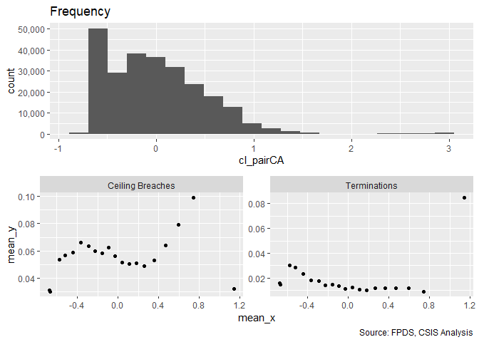

```r
 # !is.na(def_serv$cl_US6_avg_sal_lag1)&
 #  !is.na(def_serv$cl_CFTE)&
 #  !is.na(def_serv$c_pPBSC)&
 #  !is.na(def_serv$c_pOffPSC)&
 #  !is.na(def_serv$c_pairHist)&
 #  !is.na(def_serv$cl_pairCA)&

summary_continuous_plot(serv_smp,"cl_pairCA")
```

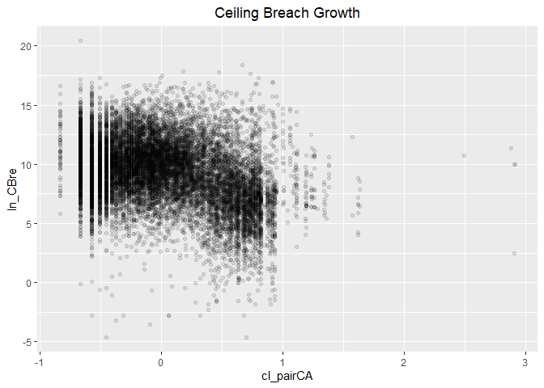

```r
#Scatter Plot
ggplot(serv_smp, aes(x=cl_pairCA, y=ln_CBre)) + geom_point(alpha = 0.1) + ggtitle('Ceiling Breach Growth') + theme(plot.title = element_text(hjust = 0.5))
```

```r
#Model
b_CBre03B <- glm (data=serv_smp,
                 b_CBre ~ cl_pairCA, family=binomial(link="logit"))
display(b_CBre03B)
```

```
## glm(formula = b_CBre ~ cl_pairCA, family = binomial(link = "logit"),
##     data = serv_smp)
##             coef.est coef.se
## (Intercept) -2.82     0.01
## cl_pairCA    0.15     0.02
## ---
##   n = 250000, k = 2
##   residual deviance = 108291.8, null deviance = 108365.4 (difference = 73.6)
```

```r
n_CBre03B <- glm(data=serv_smp,
                        ln_CBre ~ cl_pairCA)

display(n_CBre03B)
```

```
## glm(formula = ln_CBre ~ cl_pairCA, data = serv_smp)
##             coef.est coef.se
## (Intercept)  9.33     0.02
## cl_pairCA   -1.97     0.05
## ---
##   n = 15018, k = 2
##   residual deviance = 102081.9, null deviance = 114568.9 (difference = 12486.9)
##   overdispersion parameter = 6.8
##   residual sd is sqrt(overdispersion) = 2.61
```

```r
#Plot residuals versus fitted
stargazer::stargazer(b_CBre02D,b_CBre03A,b_CBre03B,

                       n_CBre02D,n_CBre03A,n_CBre03B,
                       type="text",
                       digits=2)
```

```
##
## ==========================================================================================
##                                                 Dependent variable:
##                          -----------------------------------------------------------------
##                                       b_CBre                          ln_CBre
##                                      logistic                          normal
##                             (1)        (2)        (3)        (4)        (5)        (6)
## ------------------------------------------------------------------------------------------
## cl_US6_avg_sal_lag1Const   0.05**                          1.14***
##                            (0.02)                           (0.05)
##
## cl_CFTE                   0.17***                          0.51***
##                            (0.02)                           (0.05)
##
## c_pPBSC                   -0.21***                         -0.90***
##                            (0.02)                           (0.05)
##
## c_pOffPSC                 0.76***                          -1.18***
##                            (0.02)                           (0.04)
##
## c_pairHist                           -0.10***                         -0.59***
##                                       (0.02)                           (0.05)
##
## cl_pairCA                                       0.15***                          -1.97***
##                                                  (0.02)                           (0.05)
##
## Constant                  -2.88***   -2.82***   -2.82***   9.46***    9.23***    9.33***
##                            (0.01)     (0.01)     (0.01)     (0.02)     (0.02)     (0.02)
##
## ------------------------------------------------------------------------------------------
## Observations              250,000    250,000    250,000     15,018     15,018     15,018
## Log Likelihood           -52,956.57 -54,165.57 -54,145.89 -34,421.06 -36,488.01 -35,701.81
## Akaike Inf. Crit.        105,923.10 108,335.10 108,295.80 68,852.12  72,980.03  71,407.63
## ==========================================================================================
## Note:                                                          *p<0.1; **p<0.05; ***p<0.01
```

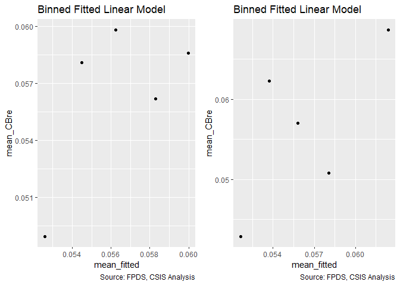

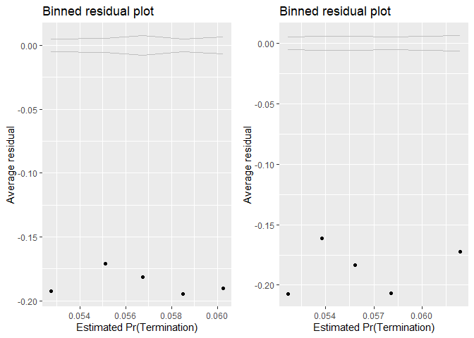

```r
summary_residual_compare(b_CBre03A,b_CBre03B, skip_vif = TRUE)
```

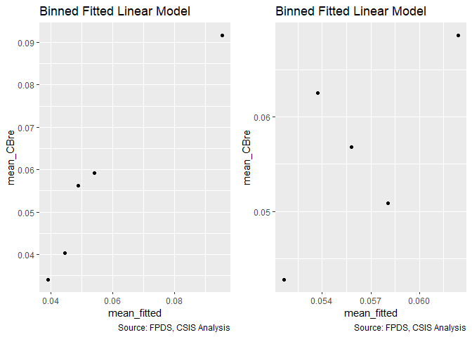

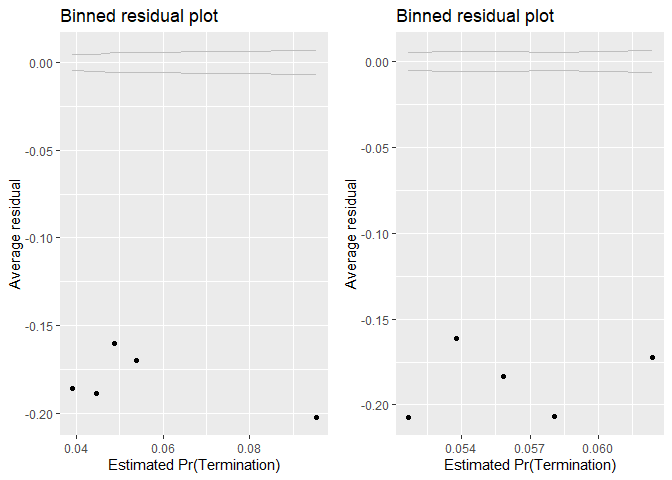

```r
summary_residual_compare(b_CBre02D,b_CBre03B, skip_vif = TRUE)
```

When considering contract actions alone, no expectation were met. The patterns in the plots are complex, ceiling breaches has a sinusoidal or perhaps exponential relationship while terminations has an neative relationship, until the number of ations grows extreme at which point the risk jumps up.

### 03C: Office-Vendor Relationship

Expectation: The importance of partnership, trust, and handling difficult problems and uncertainty together naturally lead into the last characteristic: the relationship between the contractor and buyer. The higher level of interaction provides the more opportunity to build a deeper relationship, the likelihood of cost ceiling breaches and terminations decreases and the exercised options increase for that partnership. Also we expect the result of combined model would be the same as individual models above.

```r
 # !is.na(def_serv$cl_US6_avg_sal_lag1)&
 #  !is.na(def_serv$cl_CFTE)&
 #  !is.na(def_serv$c_pPBSC)&
 #  !is.na(def_serv$c_pOffPSC)&
 #  !is.na(def_serv$c_pairHist)&
 #  !is.na(def_serv$cl_pairCA)&

#Model
b_CBre03C <- glm (data=serv_smp,
                 b_CBre ~ c_pairHist+cl_pairCA, family=binomial(link="logit"))
glmer_examine(b_CBre03C)
```

```
## c_pairHist  cl_pairCA
##   1.204205   1.204205
```

```r
n_CBre03C <- glm(data=serv_smp,
                        ln_CBre ~ c_pairHist+cl_pairCA)

glmer_examine(n_CBre03C)
```

```
## c_pairHist  cl_pairCA
##   1.256669   1.256669
```

```r
#Plot residuals versus fitted
  stargazer::stargazer(b_CBre02D,b_CBre03A,b_CBre03B,b_CBre03C,

                       n_CBre02D,n_CBre03A,n_CBre03B,n_CBre03C,
                       type="text",
                       digits=2)
```

```
##
## ================================================================================================================
##                                                            Dependent variable:
##                          ---------------------------------------------------------------------------------------
##                                            b_CBre                                      ln_CBre
##                                           logistic                                     normal
##                             (1)        (2)        (3)        (4)        (5)        (6)        (7)        (8)
## ----------------------------------------------------------------------------------------------------------------
## cl_US6_avg_sal_lag1Const   0.05**                                     1.14***
##                            (0.02)                                      (0.05)
##
## cl_CFTE                   0.17***                                     0.51***
##                            (0.02)                                      (0.05)
##
## c_pPBSC                   -0.21***                                    -0.90***
##                            (0.02)                                      (0.05)
##
## c_pOffPSC                 0.76***                                     -1.18***
##                            (0.02)                                      (0.04)
##
## c_pairHist                           -0.10***              -0.20***              -0.59***              0.33***
##                                       (0.02)                (0.02)                (0.05)                (0.05)
##
## cl_pairCA                                       0.15***    0.23***                          -1.97***   -2.12***
##                                                  (0.02)     (0.02)                           (0.05)     (0.05)
##
## Constant                  -2.88***   -2.82***   -2.82***   -2.83***   9.46***    9.23***    9.33***    9.35***
##                            (0.01)     (0.01)     (0.01)     (0.01)     (0.02)     (0.02)     (0.02)     (0.02)
##
## ----------------------------------------------------------------------------------------------------------------
## Observations              250,000    250,000    250,000    250,000     15,018     15,018     15,018     15,018
## Log Likelihood           -52,956.57 -54,165.57 -54,145.89 -54,093.45 -34,421.06 -36,488.01 -35,701.81 -35,679.33
## Akaike Inf. Crit.        105,923.10 108,335.10 108,295.80 108,192.90 68,852.12  72,980.03  71,407.63  71,364.67
## ================================================================================================================
## Note:                                                                                *p<0.1; **p<0.05; ***p<0.01
```

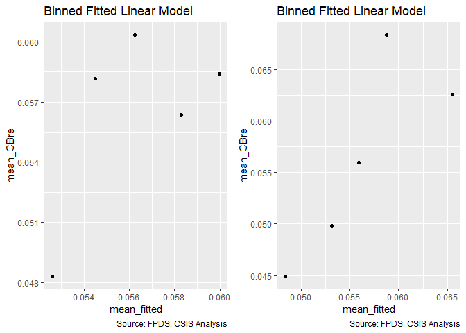

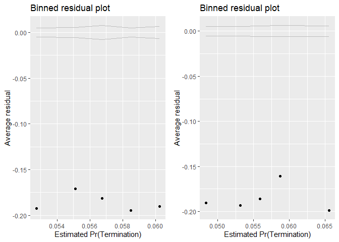

```
## [[1]]
##        model deviance null.deviance difference
## 1 model1_old 108331.1      108365.4   34.21701
## 2 model1_new 108186.9      108365.4  178.46786
##
## [[2]]
## c_pairHist  cl_pairCA
##   1.204205   1.204205
```

```r
summary_residual_compare(b_CBre03A,b_CBre03C)
```

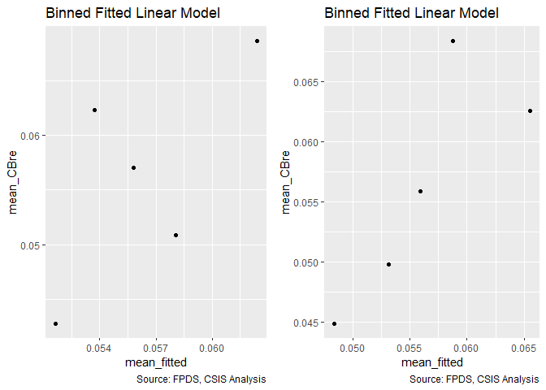

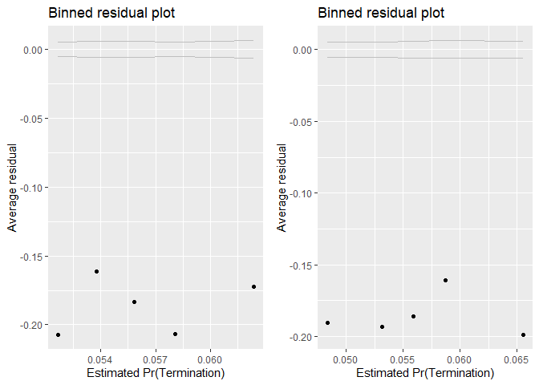

```
## [[1]]
##        model deviance null.deviance difference
## 1 model1_old 108291.8      108365.4   73.58101
## 2 model1_new 108186.9      108365.4  178.46786
##
## [[2]]
## c_pairHist  cl_pairCA
##   1.204205   1.204205
```

```r
summary_residual_compare(b_CBre03B,b_CBre03C)
```

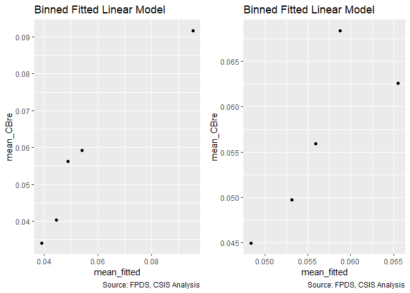

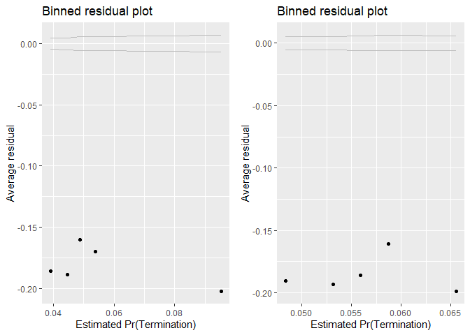

```
## [[1]]
##        model deviance null.deviance difference
## 1 model1_old 105913.1      108365.4  2452.2259
## 2 model1_new 108186.9      108365.4   178.4679
##
## [[2]]
## c_pairHist  cl_pairCA
##   1.204205   1.204205
```

```r
summary_residual_compare(b_CBre02D,b_CBre03C)
```

### 03D: Cumulative Model

Expectation: Under each subgroup, the predictors are expected to have similar impacts on dependent variables individually and cumulatively: 1. Higher Services Complexity: Higher likelihood of cost ceiling breaches and terminations; Less exercised options 2. Larger Office Capacity: Lower likelihood of cost ceiling breaches and terminations; More exercised options 3. Deeper Office-Vendor Relationship: Lower likelihood of cost ceiling breaches and terminations; More exercised options

```r
#Model
b_CBre03D <- glm (data=serv_smp,
                 b_CBre ~  cl_US6_avg_sal_lag1Const +
                   cl_CFTE+ c_pPBSC+c_pOffPSC+
                 c_pairHist+cl_pairCA, family=binomial(link="logit"))
glmer_examine(b_CBre03D)
```

```
## cl_US6_avg_sal_lag1Const                  cl_CFTE                  c_pPBSC
##                 1.224892                 1.167672                 1.274248
##                c_pOffPSC               c_pairHist                cl_pairCA
##                 1.448092                 1.244916                 1.540912
```

```r
n_CBre03D <- glm(data=serv_smp,
                        ln_CBre ~  cl_US6_avg_sal_lag1Const +
                   cl_CFTE+ c_pPBSC+c_pOffPSC+
                 c_pairHist+cl_pairCA)

glmer_examine(n_CBre03D)
```

```
## cl_US6_avg_sal_lag1Const                  cl_CFTE                  c_pPBSC
##                 1.263030                 1.228679                 2.196997
##                c_pOffPSC               c_pairHist                cl_pairCA
##                 2.748796                 1.311458                 2.089061
```

```r
#Plot residuals versus fitted

stargazer::stargazer(b_CBre02D,b_CBre03C,b_CBre03D,

                       n_CBre02D,n_CBre03C,n_CBre03D,
                       type="text",
                       digits=2)
```

```
##
## ==========================================================================================
##                                                 Dependent variable:
##                          -----------------------------------------------------------------
##                                       b_CBre                          ln_CBre
##                                      logistic                          normal
##                             (1)        (2)        (3)        (4)        (5)        (6)
## ------------------------------------------------------------------------------------------
## cl_US6_avg_sal_lag1Const   0.05**               0.09***    1.14***               1.20***
##                            (0.02)                (0.02)     (0.05)                (0.05)
##
## cl_CFTE                   0.17***               0.16***    0.51***               0.48***
##                            (0.02)                (0.02)     (0.05)                (0.05)
##
## c_pPBSC                   -0.21***              -0.18***   -0.90***              -0.85***
##                            (0.02)                (0.02)     (0.05)                (0.05)
##
## c_pOffPSC                 0.76***               0.81***    -1.18***              -0.98***
##                            (0.02)                (0.02)     (0.04)                (0.04)
##
## c_pairHist                           -0.20***   -0.16***              0.33***     0.09**
##                                       (0.02)     (0.02)                (0.05)     (0.05)
##
## cl_pairCA                            0.23***    -0.13***              -2.12***   -0.62***
##                                       (0.02)     (0.02)                (0.05)     (0.06)
##
## Constant                  -2.88***   -2.83***   -2.88***   9.46***    9.35***    9.44***
##                            (0.01)     (0.01)     (0.01)     (0.02)     (0.02)     (0.02)
##
## ------------------------------------------------------------------------------------------
## Observations              250,000    250,000    250,000     15,018     15,018     15,018
## Log Likelihood           -52,956.57 -54,093.45 -52,872.69 -34,421.06 -35,679.33 -34,366.59
## Akaike Inf. Crit.        105,923.10 108,192.90 105,759.40 68,852.12  71,364.67  68,747.18
## ==========================================================================================
## Note:                                                          *p<0.1; **p<0.05; ***p<0.01
```

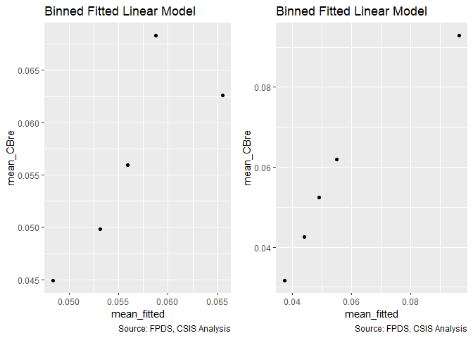

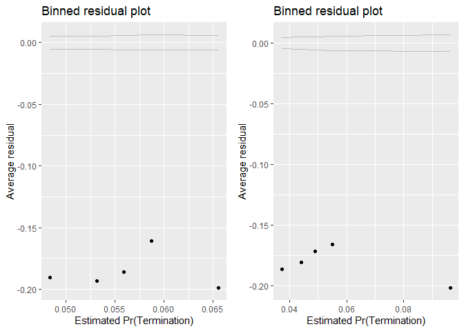

```
## [[1]]
##        model deviance null.deviance difference
## 1 model1_old 108186.9      108365.4   178.4679
## 2 model1_new 105745.4      108365.4  2619.9862
##
## [[2]]
## cl_US6_avg_sal_lag1Const                  cl_CFTE                  c_pPBSC
##                 1.224892                 1.167672                 1.274248
##                c_pOffPSC               c_pairHist                cl_pairCA
##                 1.448092                 1.244916                 1.540912
```

```r
summary_residual_compare(b_CBre03C,b_CBre03D)
```

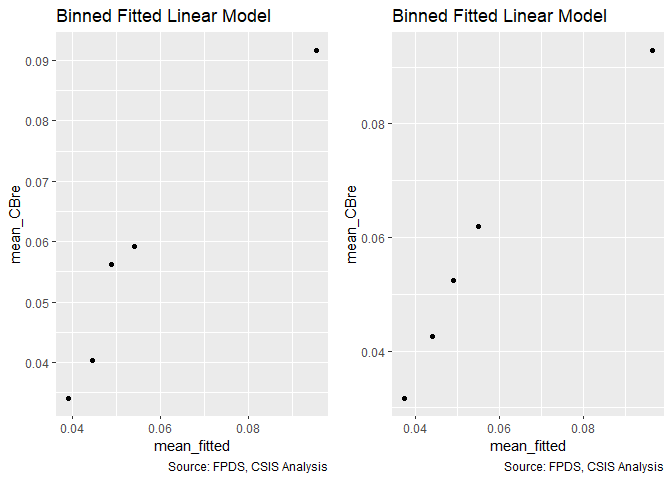

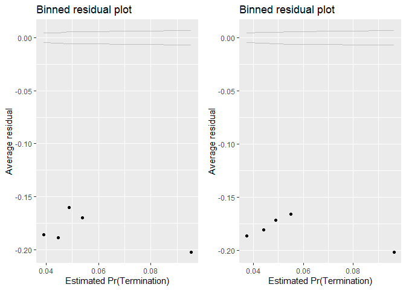

```
## [[1]]
##        model deviance null.deviance difference
## 1 model1_old 105913.1      108365.4   2452.226
## 2 model1_new 105745.4      108365.4   2619.986
##
## [[2]]
## cl_US6_avg_sal_lag1Const                  cl_CFTE                  c_pPBSC
##                 1.224892                 1.167672                 1.274248
##                c_pOffPSC               c_pairHist                cl_pairCA
##                 1.448092                 1.244916                 1.540912
```

```r
summary_residual_compare(b_CBre02D,b_CBre03D)
```

1. Ceiling breaches: A. Service Complexity: The relationship with average salary gained significance in line with expectation. The result for both average salary and invoice rate matched with expectation.

B. Office Capacity: The relationship with PBSC matched with expectation but with less magnitude. The result for office obligations did not match with expectation.

C. Office-Vendor Relationship: The result for pair history matched with expectation The relationship with contract actions reverse and now align with expectations.

2. Terminations: A. Service Complexity: The reult for average salary did not match with expectation. The result for invoice rate did matach with expectation, only significant (for p-value <0.5), which is still sufficient.

B. Office Capacity: The relationship with PBSC was not significant. The result for office obligations did not match with expectation.

C. Office-Vendor Relationship: The result for pair history matched with expectation once all variables included. The result for contract actions did not match with expectation.

3. Exercised Options: A. Service Complexity: The result for both average salary and invoice rate matached with expectation but with less magnitude.

B. Office Capacity: The result for PBSC didn’t match with expectation. The result for office obligations matched with expectation.

C. Office-Vendor Relationship: The result for pair history lost significance and didn’t match with expectations. The result for contract actions didn’t match with expectation.

## Study Variables Alone

```r
 # !is.na(def_serv$cl_US6_avg_sal_lag1)&
 #  !is.na(def_serv$cl_CFTE)&
 #  !is.na(def_serv$c_pPBSC)&
 #  !is.na(def_serv$c_pOffPSC)&
 #  !is.na(def_serv$c_pairHist)&
 #  !is.na(def_serv$cl_pairCA)&


study_coef_list<-list("(Intercept)"="(Intercept)",
                      "cl_US6_avg_sal_lag1Const"="Log(Det. Ind. Salary)",
                      "cl_CFTE"="Log(Service Invoice Rate)",
                      "c_pPBSC"="Office Perf.-Based %",
                      "c_pOffPSC"="Office Service Exp. %",
                      "c_pairHist"="Paired Years",
                      "cl_pairCA"="Log(Paired Actions)"
)

all_coef_list<-list("(Intercept)"="(Intercept)",
                    "cl_US6_avg_sal_lag1Const"="Log(Det. Ind. Salary)",
                    "cl_CFTE"="Log(Service Invoice Rate)",
                    "c_pPBSC"="Office Perf.-Based %",
                    "c_pOffPSC"="Office Service Exp. %",
                    "c_pairHist"="Paired Years",
                    "cl_pairCA"="Log(Paired Actions)",

                    #Contract Controls

                    "Comp1or51 offer"="Comp=1 offer",
                    "Comp1or52-4 offers"="Comp=2-4 offers",
                    "Comp1or55+ offers"="Comp=5+ offers",

                    "CompOffr1 offer"="Comp=1 offer",
                    "CompOffr2 offers"="Comp=2 offers",
                    "CompOffr3-4 offers"="Comp=3-4 offers",
                    "CompOffr5+ offers"="Comp=5+ offers",

                    "cl_Ceil"="Log(Init. Ceiling)",
                    "capped_cl_Days"="Log(Init. Days)",
                    "VehS-IDC"="Vehicle=S-IDC",
                    "VehM-IDC"="Vehicle=M-IDC",
                    "VehFSS/GWAC"="Vehicle=FSS/GWAC",
                    "VehBPA/BOA"="Vehicle=BPA/BOA",
                    "PricingUCAFFP"="Pricing=FFP",
                    "PricingUCAOther FP"="Pricing=Other FP",
                    "PricingUCAIncentive"="Pricing=Incentive Fee",
                    "PricingUCACombination or Other"="Pricing=Combination or Other",
                    "PricingUCAOther CB"="Pricing=Other CB",
                    "PricingUCAT&M/LH/FPLOE"="Pricing=T&M/LH/FP:LoE",
                    "PricingUCAUCA"="Pricing=UCA",

                    "PricingFeeOther FP"="Pricing=Other FP",
                    "PricingFeeIncentive"="Pricing=Incentive Fee",
                    "PricingFeeCombination or Other"="Pricing=Combination or Other",
                    "PricingFeeOther CB"="Pricing=Other CB",
                    "PricingFeeT&M/LH/FPLOE"="Pricing=T&M/LH/FP:LoE",
                    "b_UCA"="UCA",
                    "CrisisARRA"="Crisis=ARRA",
                    "CrisisDis"="Crisis=Disaster",
                    "CrisisOCO"="Crisis=OCO",
                    "b_Intl"="Performed Abroad",

                    #NAICS
                    "cl_def3_HHI_lag1"="Log(Subsector HHI)",
                    "cl_def6_HHI_lag1"="Log(Det. Ind. HHI)",
                    "cl_def3_ratio_lag1"="Log(Subsector Ratio)",
                    "cl_def6_obl_lag1"="Log(Det. Ind. DoD Obl.)",
                    "cl_def6_ratio_lag1"="Log(Det. Ind. Ratio)",
                    #Office
                    "c_pMarket"="Percent Market",
                    "cl_OffVol"="Office Volume",
                    "cl_office_naics_hhi_k"="Office Concentration",


                    #interations
                    # # "cl_def6_HHI_lag1:capped_cl_Days"="Log(Det. Ind. HHI):Log(Init. Days)",
                    # "cl_def6_HHI_lag1:cl_def6_obl_lag1"="Log(Det. Ind. HHI):Log(Det. Ind. DoD Obl.)",
                    # # "cl_def3_HHI_lag1:cl_def3_ratio_lag1"="Log(Subsector HHI):Log(Subsector Ratio)"),
                    "cl_def6_HHI_lag1:b_UCA"="Log(Det. Ind. HHI):UCA",
                    # "cl_Ceil:b_UCA"="Log(Init. Ceiling):UCA",
                    # "CompOffr1 offer:b_UCA"="Comp=1 offer:UCA",
                    # "CompOffr2 offers:b_UCA"="Comp=2 offers:UCA",
                    # "CompOffr3-4 offers:b_UCA"="Comp=3-4 offers:UCA",
                    # "CompOffr5+ offers:b_UCA"="Comp=5+ offers:UCA"
                    "VehS-IDC:b_Intl"="Vehicle=S-IDC:Performed Abroad",
                    "VehM-IDC:b_Intl"="Vehicle=M-IDC:Performed Abroad",
                    "VehFSS/GWAC:b_Intl"="Vehicle=FSS/GWAC:Performed Abroad",
                    "VehBPA/BOA:b_Intl"="Vehicle=BPA/BOA:Performed Abroad",
                    "cl_US6_avg_sal_lag1:PricingFeeOther FP"="Pricing=Other FP:Log(Det. Ind. U.S. Avg. Salary)",
                    "cl_US6_avg_sal_lag1:PricingFeeIncentive"="Pricing=Incentive Fee:Log(Det. Ind. U.S. Avg. Salary)",
                    "cl_US6_avg_sal_lag1:PricingFeeCombination or Other"="Pricing=Comb./or Other:Log(Det. Ind. U.S. Avg. Salary)",
                    "cl_US6_avg_sal_lag1:PricingFeeOther CB"="Pricing=Other CB:Log(Det. Ind. U.S. Avg. Salary)",
                    "cl_US6_avg_sal_lag1:PricingFeeT&M/LH/FPLOE"="Pricing=T&M/LH/FP:LoE:Log(Det. Ind. U.S. Avg. Salary)"
)




#Ceiling Breaches Binary
  stargazer::stargazer(b_CBre01A,b_CBre01B,b_CBre02A,b_CBre02B,b_CBre03A,b_CBre03B,b_CBre03D,
                       type="text",
                       digits=2)
```

```
##
## =====================================================================================================
##                                                      Dependent variable:
##                          ----------------------------------------------------------------------------
##                                                             b_CBre
##                             (1)        (2)        (3)        (4)        (5)        (6)        (7)
## -----------------------------------------------------------------------------------------------------
## cl_US6_avg_sal_lag1Const  0.21***                                                           0.09***
##                            (0.02)                                                            (0.02)
##
## cl_CFTE                              0.19***                                                0.16***
##                                       (0.02)                                                 (0.02)
##
## c_pPBSC                                         0.15***                                     -0.18***
##                                                  (0.02)                                      (0.02)
##
## c_pOffPSC                                                  0.69***                          0.81***
##                                                             (0.01)                           (0.02)
##
## c_pairHist                                                            -0.10***              -0.16***
##                                                                        (0.02)                (0.02)
##
## cl_pairCA                                                                        0.15***    -0.13***
##                                                                                   (0.02)     (0.02)
##
## Constant                  -2.82***   -2.82***   -2.82***   -2.87***   -2.82***   -2.82***   -2.88***
##                            (0.01)     (0.01)     (0.01)     (0.01)     (0.01)     (0.01)     (0.01)
##
## -----------------------------------------------------------------------------------------------------
## Observations              250,000    250,000    250,000    250,000    250,000    250,000    250,000
## Log Likelihood           -54,112.11 -54,122.07 -54,142.39 -53,074.74 -54,165.57 -54,145.89 -52,872.69
## Akaike Inf. Crit.        108,228.20 108,248.10 108,288.80 106,153.50 108,335.10 108,295.80 105,759.40
## =====================================================================================================
## Note:                                                                     *p<0.1; **p<0.05; ***p<0.01
```

```r
texreg::htmlreg(list(b_CBre01A,b_CBre01B,b_CBre02A,b_CBre02B,b_CBre03A,b_CBre03B,b_CBre03D),file="..//Output//b_CBreModel.html",
                single.row = TRUE,
                # custom.model.name=c("Ceiling Breaches"),
                stars=c(0.1,0.05,0.01,0.001),
                groups = list(
                              "Services Complexity" = 2:3,
                              "Office Capacity" =4:5,
                              "Past Relationship"=6:7
                              ),
                custom.coef.map=all_coef_list,
                bold=0.05,
                custom.note="%stars. Numerical inputs are rescaled.",
                caption="Table 6: Logit Bivariate Look at Study Variables and Ceiling Breaches",
                caption.above=TRUE)
```

```
## The table was written to the file '..//Output//b_CBreModel.html'.
```

```r
#Ceiling Breach Absolute
stargazer::stargazer(n_CBre01A,n_CBre01B,n_CBre02A,n_CBre02B,n_CBre03A,n_CBre03B,n_CBre03D,
                       type="text",
                       digits=2)
```

```
##
## =====================================================================================================
##                                                      Dependent variable:
##                          ----------------------------------------------------------------------------
##                                                            ln_CBre
##                             (1)        (2)        (3)        (4)        (5)        (6)        (7)
## -----------------------------------------------------------------------------------------------------
## cl_US6_avg_sal_lag1Const  0.78***                                                           1.20***
##                            (0.06)                                                            (0.05)
##
## cl_CFTE                              1.20***                                                0.48***
##                                       (0.05)                                                 (0.05)
##
## c_pPBSC                                         -1.90***                                    -0.85***
##                                                  (0.04)                                      (0.05)
##
## c_pOffPSC                                                  -1.62***                         -0.98***
##                                                             (0.03)                           (0.04)
##
## c_pairHist                                                            -0.59***               0.09**
##                                                                        (0.05)                (0.05)
##
## cl_pairCA                                                                        -1.97***   -0.62***
##                                                                                   (0.05)     (0.06)
##
## Constant                  9.21***    9.20***    9.33***    9.60***    9.23***    9.33***    9.44***
##                            (0.02)     (0.02)     (0.02)     (0.02)     (0.02)     (0.02)     (0.02)
##
## -----------------------------------------------------------------------------------------------------
## Observations               15,018     15,018     15,018     15,018     15,018     15,018     15,018
## Log Likelihood           -36,467.62 -36,251.56 -35,243.81 -35,027.39 -36,488.01 -35,701.81 -34,366.59
## Akaike Inf. Crit.        72,939.24  72,507.12  70,491.63  70,058.78  72,980.03  71,407.63  68,747.18
## =====================================================================================================
## Note:                                                                     *p<0.1; **p<0.05; ***p<0.01
```

```r
texreg::htmlreg(list(n_CBre01A,n_CBre01B,n_CBre02A,n_CBre02B,n_CBre03A,n_CBre03B,n_CBre03D),file="..//Output//n_CBreModel.html",
                single.row = TRUE,
                # custom.model.name=c("Ceiling Breaches"),
                stars=c(0.1,0.05,0.01,0.001),
                groups = list(
                              "Services Complexity" = 2:3,
                              "Office Capacity" =4:5,
                              "Past Relationship"=6:7
                              ),
                custom.coef.map=all_coef_list,
                bold=0.05,
                custom.note="%stars. Numerical inputs are rescaled.",
                caption="Table 8: Regression Bivariate Look at Study Variables and Log(Options Growth)",
                caption.above=TRUE)
```

```
## The table was written to the file '..//Output//n_CBreModel.html'.
```

# Controls

## Contract-Level Controls

### Scope Variables

#### 04A: Cost Ceiling

Expectation: Initial Ceiling size positively estimates increasing probability of ceiling breaches and terminations and negatively estimates the option growth. Terminations and ceiling breaches simply comes down to large being associated with higher risk, while for option growth size imply makes it harder to grow proportionally.

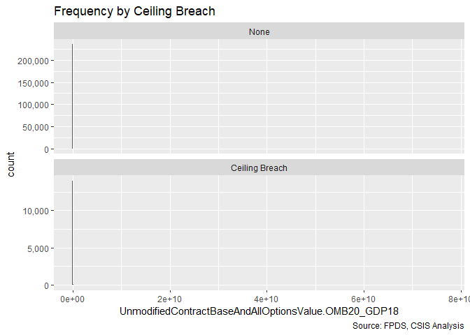

```r
#Frequency Plot for unlogged ceiling
freq_continuous_cbre_plot(serv_smp,"UnmodifiedContractBaseAndAllOptionsValue.OMB20_GDP18",
               bins=1000)
```

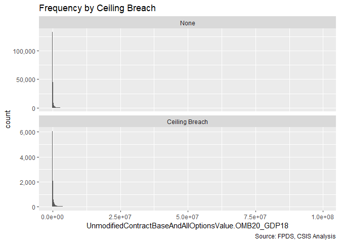

```r
freq_continuous_cbre_plot(subset(serv_smp,UnmodifiedContractBaseAndAllOptionsValue.OMB20_GDP18<100000000),
               "UnmodifiedContractBaseAndAllOptionsValue.OMB20_GDP18",
               bins=1000)
```

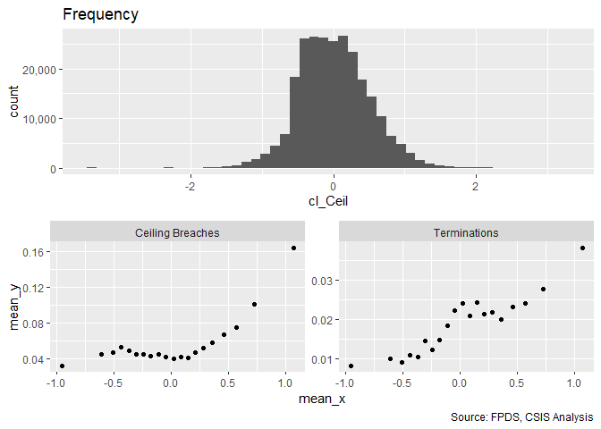

```r
summary_continuous_plot(serv_smp,"cl_Ceil",bins=50)
```

```r
summary(serv_smp$cl_Ceil)
```

```
##     Min.  1st Qu.   Median     Mean  3rd Qu.     Max.
## -3.39507 -0.33658 -0.01169  0.01033  0.31835  3.24200
```

```r
str(serv_smp)
```

[output not shown]

[output cut: 101 more lines]

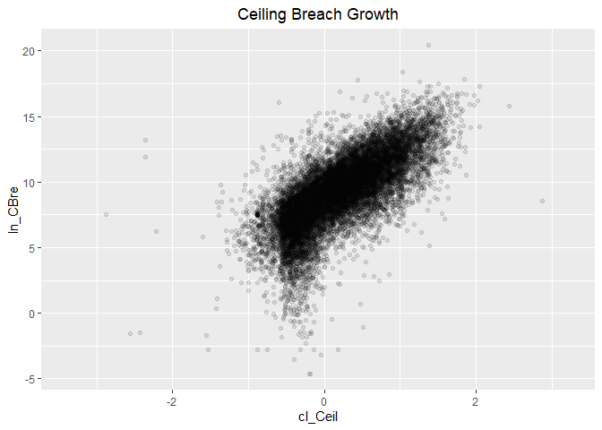

```r
#Scatter Plot
ggplot(serv_smp, aes(x=cl_Ceil, y=ln_CBre)) + geom_point(alpha = 0.1) + ggtitle('Ceiling Breach Growth') + theme(plot.title = element_text(hjust = 0.5))
```

```r
#Model
b_CBre04A <- glm (data=serv_smp,
                 b_CBre ~ cl_Ceil, family=binomial(link="logit"))
display(b_CBre04A)
```

```
## glm(formula = b_CBre ~ cl_Ceil, family = binomial(link = "logit"),
##     data = serv_smp)
##             coef.est coef.se
## (Intercept) -2.90     0.01
## cl_Ceil      0.85     0.02
## ---
##   n = 250000, k = 2
##   residual deviance = 106032.9, null deviance = 108365.4 (difference = 2332.5)
```

```r
n_CBre04A <- glm(data=serv_smp,
                        ln_CBre ~ cl_Ceil)

display(n_CBre04A)
```

```
## glm(formula = ln_CBre ~ cl_Ceil, data = serv_smp)
##             coef.est coef.se
## (Intercept) 8.54     0.02
## cl_Ceil     3.51     0.03
## ---
##   n = 15018, k = 2
##   residual deviance = 54941.0, null deviance = 114568.9 (difference = 59627.8)
##   overdispersion parameter = 3.7
##   residual sd is sqrt(overdispersion) = 1.91
```

```r
#Plot residuals versus fitted
stargazer::stargazer(b_CBre03D,b_CBre04A,

                       n_CBre03D,n_CBre04A,
                       type="text",
                       digits=2)
```

```
##
## ====================================================================
##                                      Dependent variable:
##                          -------------------------------------------
##                                 b_CBre                ln_CBre
##                                logistic               normal
##                             (1)        (2)        (3)        (4)
## --------------------------------------------------------------------
## cl_US6_avg_sal_lag1Const  0.09***               1.20***
##                            (0.02)                (0.05)
##
## cl_CFTE                   0.16***               0.48***
##                            (0.02)                (0.05)
##
## c_pPBSC                   -0.18***              -0.85***
##                            (0.02)                (0.05)
##
## c_pOffPSC                 0.81***               -0.98***
##                            (0.02)                (0.04)
##
## c_pairHist                -0.16***               0.09**
##                            (0.02)                (0.05)
##
## cl_pairCA                 -0.13***              -0.62***
##                            (0.02)                (0.06)
##
## cl_Ceil                              0.85***               3.51***
##                                       (0.02)                (0.03)
##
## Constant                  -2.88***   -2.90***   9.44***    8.54***
##                            (0.01)     (0.01)     (0.02)     (0.02)
##
## --------------------------------------------------------------------
## Observations              250,000    250,000     15,018     15,018
## Log Likelihood           -52,872.69 -53,016.45 -34,366.59 -31,049.87
## Akaike Inf. Crit.        105,759.40 106,036.90 68,747.18  62,103.75
## ====================================================================
## Note:                                    *p<0.1; **p<0.05; ***p<0.01
```

```r
#summary_residual_compare(b_CBre03D,b_CBre04A, skip_vif = TRUE)
```

#### 04B: Maximum Duration

Expectation: Greater maximum duration will positively estimate the probability ceiling of breaches and terminations. Greater growth for options is also expected, because year-on-year options may be more of a default, though the scatter plot seems to go the other way.

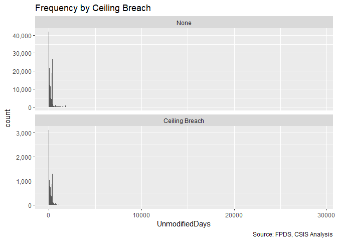

```r
#Frequency Plot for max duration
freq_continuous_cbre_plot(serv_smp,"UnmodifiedDays",
               bins=1000)
```

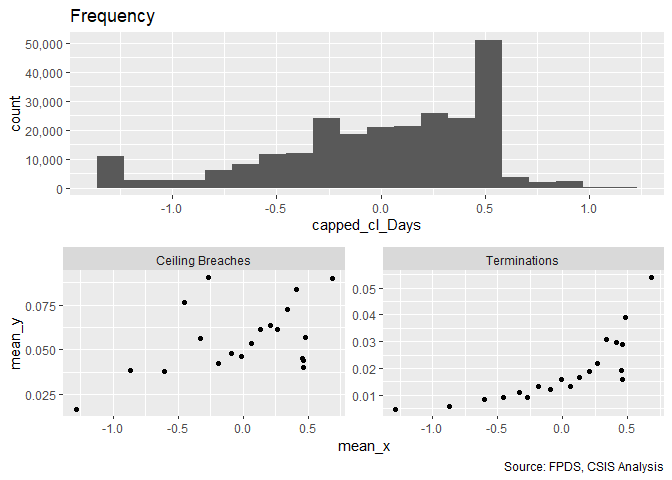

```r
summary_continuous_plot(serv_smp,"capped_cl_Days")
```

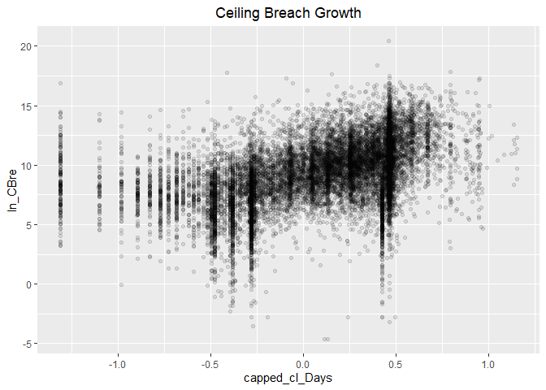

```r
#Scatter Plot
ggplot(serv_smp, aes(x=capped_cl_Days, y=ln_CBre)) + geom_point(alpha = 0.1) + ggtitle('Ceiling Breach Growth') + theme(plot.title = element_text(hjust = 0.5))
```

```r
#Model
b_CBre04B <- glm (data=serv_smp,
                 b_CBre ~ capped_cl_Days, family=binomial(link="logit"))
display(b_CBre04B)
```

```
## glm(formula = b_CBre ~ capped_cl_Days, family = binomial(link = "logit"),
##     data = serv_smp)
##                coef.est coef.se
## (Intercept)    -2.83     0.01
## capped_cl_Days  0.34     0.02
## ---
##   n = 250000, k = 2
##   residual deviance = 108010.3, null deviance = 108365.4 (difference = 355.1)
```

```r
n_CBre04B <- glm(data=serv_smp,
                        ln_CBre ~ capped_cl_Days)

display(n_CBre04B)
```

```
## glm(formula = ln_CBre ~ capped_cl_Days, data = serv_smp)
##                coef.est coef.se
## (Intercept)    9.05     0.02
## capped_cl_Days 2.91     0.05
## ---
##   n = 15018, k = 2
##   residual deviance = 91284.8, null deviance = 114568.9 (difference = 23284.1)
##   overdispersion parameter = 6.1
##   residual sd is sqrt(overdispersion) = 2.47
```

```r
#Plot residuals versus fitted
stargazer::stargazer(b_CBre03D,b_CBre04A,b_CBre04B,

                       n_CBre03D,n_CBre04A,n_CBre04B,
                       type="text",
                       digits=2)
```

```
##
## ==========================================================================================
##                                                 Dependent variable:
##                          -----------------------------------------------------------------
##                                       b_CBre                          ln_CBre
##                                      logistic                          normal
##                             (1)        (2)        (3)        (4)        (5)        (6)
## ------------------------------------------------------------------------------------------
## cl_US6_avg_sal_lag1Const  0.09***                          1.20***
##                            (0.02)                           (0.05)
##
## cl_CFTE                   0.16***                          0.48***
##                            (0.02)                           (0.05)
##
## c_pPBSC                   -0.18***                         -0.85***
##                            (0.02)                           (0.05)
##
## c_pOffPSC                 0.81***                          -0.98***
##                            (0.02)                           (0.04)
##
## c_pairHist                -0.16***                          0.09**
##                            (0.02)                           (0.05)
##
## cl_pairCA                 -0.13***                         -0.62***
##                            (0.02)                           (0.06)
##
## cl_Ceil                              0.85***                          3.51***
##                                       (0.02)                           (0.03)
##
## capped_cl_Days                                  0.34***                          2.91***
##                                                  (0.02)                           (0.05)
##
## Constant                  -2.88***   -2.90***   -2.83***   9.44***    8.54***    9.05***
##                            (0.01)     (0.01)     (0.01)     (0.02)     (0.02)     (0.02)
##
## ------------------------------------------------------------------------------------------
## Observations              250,000    250,000    250,000     15,018     15,018     15,018
## Log Likelihood           -52,872.69 -53,016.45 -54,005.13 -34,366.59 -31,049.87 -34,862.37
## Akaike Inf. Crit.        105,759.40 106,036.90 108,014.30 68,747.18  62,103.75  69,728.74
## ==========================================================================================
## Note:                                                          *p<0.1; **p<0.05; ***p<0.01
```

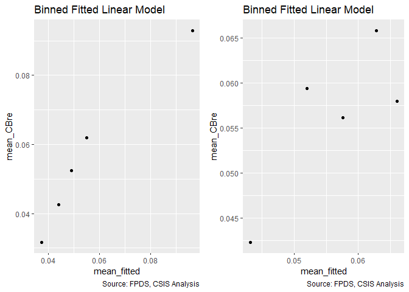

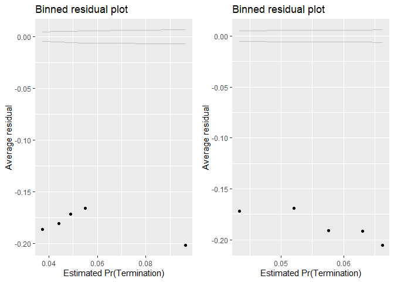

```r
summary_residual_compare(b_CBre03D,b_CBre04B, skip_vif = TRUE)
```

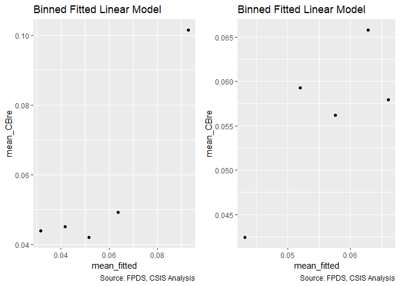

[figure not shown]

```r
summary_residual_compare(b_CBre04A,b_CBre04B, skip_vif = TRUE)
```

All expections were upheld.

#### 04C: Both Scope variables

```r
#Model
b_CBre04C <- glm (data=serv_smp,
                 b_CBre ~ cl_Ceil + capped_cl_Days, family=binomial(link="logit"))
display(b_CBre04C)
```

```
## glm(formula = b_CBre ~ cl_Ceil + capped_cl_Days, family = binomial(link = "logit"),
##     data = serv_smp)
##                coef.est coef.se
## (Intercept)    -2.90     0.01
## cl_Ceil         0.88     0.02
## capped_cl_Days -0.06     0.02
## ---
##   n = 250000, k = 3
##   residual deviance = 106024.5, null deviance = 108365.4 (difference = 2340.8)
```

```r
n_CBre04C <- glm(data=serv_smp,
                        ln_CBre ~cl_Ceil + capped_cl_Days)

display(n_CBre04C)
```

```
## glm(formula = ln_CBre ~ cl_Ceil + capped_cl_Days, data = serv_smp)
##                coef.est coef.se
## (Intercept)    8.54     0.02
## cl_Ceil        3.35     0.03
## capped_cl_Days 0.37     0.04
## ---
##   n = 15018, k = 3
##   residual deviance = 54689.5, null deviance = 114568.9 (difference = 59879.4)
##   overdispersion parameter = 3.6
##   residual sd is sqrt(overdispersion) = 1.91
```

```r
#Plot residuals versus fitted
stargazer::stargazer(b_CBre03D,b_CBre04A,b_CBre04B,b_CBre04C,

                       n_CBre03D,n_CBre04A,n_CBre04B,n_CBre04C,
                       type="text",
                       digits=2)
```

```
##
## ================================================================================================================
##                                                            Dependent variable:
##                          ---------------------------------------------------------------------------------------
##                                            b_CBre                                      ln_CBre
##                                           logistic                                     normal
##                             (1)        (2)        (3)        (4)        (5)        (6)        (7)        (8)
## ----------------------------------------------------------------------------------------------------------------
## cl_US6_avg_sal_lag1Const  0.09***                                     1.20***
##                            (0.02)                                      (0.05)
##
## cl_CFTE                   0.16***                                     0.48***
##                            (0.02)                                      (0.05)
##
## c_pPBSC                   -0.18***                                    -0.85***
##                            (0.02)                                      (0.05)
##
## c_pOffPSC                 0.81***                                     -0.98***
##                            (0.02)                                      (0.04)
##
## c_pairHist                -0.16***                                     0.09**
##                            (0.02)                                      (0.05)
##
## cl_pairCA                 -0.13***                                    -0.62***
##                            (0.02)                                      (0.06)
##
## cl_Ceil                              0.85***               0.88***               3.51***               3.35***
##                                       (0.02)                (0.02)                (0.03)                (0.03)
##
## capped_cl_Days                                  0.34***    -0.06***                         2.91***    0.37***
##                                                  (0.02)     (0.02)                           (0.05)     (0.04)
##
## Constant                  -2.88***   -2.90***   -2.83***   -2.90***   9.44***    8.54***    9.05***    8.54***
##                            (0.01)     (0.01)     (0.01)     (0.01)     (0.02)     (0.02)     (0.02)     (0.02)
##
## ----------------------------------------------------------------------------------------------------------------
## Observations              250,000    250,000    250,000    250,000     15,018     15,018     15,018     15,018
## Log Likelihood           -52,872.69 -53,016.45 -54,005.13 -53,012.26 -34,366.59 -31,049.87 -34,862.37 -31,015.42
## Akaike Inf. Crit.        105,759.40 106,036.90 108,014.30 106,030.50 68,747.18  62,103.75  69,728.74  62,036.83
## ================================================================================================================
## Note:                                                                                *p<0.1; **p<0.05; ***p<0.01
```

```r
#summary_residual_compare(b_CBre03D,b_CBre04C)
#summary_residual_compare(b_CBre04A,b_CBre04C)
#summary_residual_compare(b_CBre04B,b_CBre04C)
```

#### 04D: Cumulative Model

```r
#Model
b_CBre04D <- glm (data=serv_smp,
                 b_CBre ~  cl_US6_avg_sal_lag1Const +
                   cl_CFTE+ c_pPBSC+c_pOffPSC+
                 c_pairHist+cl_pairCA +
                   cl_Ceil + capped_cl_Days, family=binomial(link="logit"))
glmer_examine(b_CBre04D)
```

```
## cl_US6_avg_sal_lag1Const                  cl_CFTE                  c_pPBSC
##                 1.341846                 1.192448                 1.248130
##                c_pOffPSC               c_pairHist                cl_pairCA
##                 1.437180                 1.241285                 1.522493
##                  cl_Ceil           capped_cl_Days
##                 1.324091                 1.323638
```

```r
n_CBre04D <- glm(data=serv_smp,
                        ln_CBre ~  cl_US6_avg_sal_lag1Const +
                   cl_CFTE+ c_pPBSC+c_pOffPSC+
                 c_pairHist+cl_pairCA+
                 cl_Ceil + capped_cl_Days)

glmer_examine(n_CBre04D)
```

```
## cl_US6_avg_sal_lag1Const                  cl_CFTE                  c_pPBSC
##                 1.327450                 1.237693                 2.239705
##                c_pOffPSC               c_pairHist                cl_pairCA
##                 2.818763                 1.323617                 2.134338
##                  cl_Ceil           capped_cl_Days
##                 1.701527                 1.565840
```

```r
#Plot residuals versus fitted

stargazer::stargazer(b_CBre03D,b_CBre04C,b_CBre04D,

                       n_CBre03D,n_CBre04C,n_CBre04D,
                       type="text",
                       digits=2)
```

```
##
## ==========================================================================================
##                                                 Dependent variable:
##                          -----------------------------------------------------------------
##                                       b_CBre                          ln_CBre
##                                      logistic                          normal
##                             (1)        (2)        (3)        (4)        (5)        (6)
## ------------------------------------------------------------------------------------------
## cl_US6_avg_sal_lag1Const  0.09***               -0.14***   1.20***               0.40***
##                            (0.02)                (0.02)     (0.05)                (0.04)
##
## cl_CFTE                   0.16***               0.09***    0.48***               0.21***
##                            (0.02)                (0.02)     (0.05)                (0.04)
##
## c_pPBSC                   -0.18***              -0.15***   -0.85***              -0.32***
##                            (0.02)                (0.02)     (0.05)                (0.04)
##
## c_pOffPSC                 0.81***               0.92***    -0.98***              -0.57***
##                            (0.02)                (0.02)     (0.04)                (0.03)
##
## c_pairHist                -0.16***              -0.15***    0.09**               0.13***
##                            (0.02)                (0.02)     (0.05)                (0.04)
##
## cl_pairCA                 -0.13***              -0.16***   -0.62***                0.06
##                            (0.02)                (0.02)     (0.06)                (0.05)
##
## cl_Ceil                              0.88***    0.93***               3.35***    3.02***
##                                       (0.02)     (0.02)                (0.03)     (0.03)
##
## capped_cl_Days                       -0.06***     0.02                0.37***     0.11**
##                                       (0.02)     (0.02)                (0.04)     (0.04)
##
## Constant                  -2.88***   -2.90***   -2.98***   9.44***    8.54***    8.74***
##                            (0.01)     (0.01)     (0.01)     (0.02)     (0.02)     (0.02)
##
## ------------------------------------------------------------------------------------------
## Observations              250,000    250,000    250,000     15,018     15,018     15,018
## Log Likelihood           -52,872.69 -53,012.26 -51,550.71 -34,366.59 -31,015.42 -30,485.79
## Akaike Inf. Crit.        105,759.40 106,030.50 103,119.40 68,747.18  62,036.83  60,989.58
## ==========================================================================================
## Note:                                                          *p<0.1; **p<0.05; ***p<0.01
```

```r
#summary_residual_compare(b_CBre03D,b_CBre04D)
#summary_residual_compare(b_CBre04C,b_CBre04D)
```

Salary no longer matches expectations for ceiling breaches. Invoice rate is no longer significant for terminations.

### Competition

#### 05A: No Competition / 1 / 2-4 / 5+ Offers

Expectations No Competition (Baseline) + - - 1 Offer + - - 2-4 Offers - + + 5+ Offers - + -

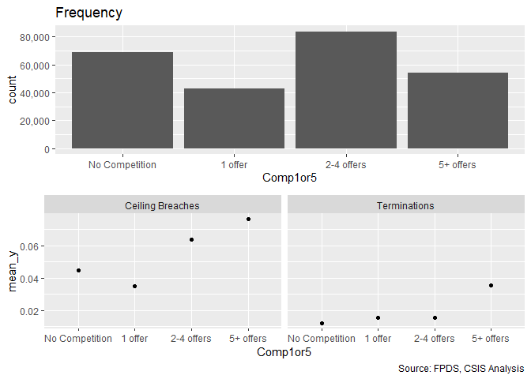

```
## [[1]]
##
## No Competition        1 offer     2-4 offers      5+ offers
##          69125          42676          83959          54240
##
## [[2]]
##
##                   None Ceiling Breach
##   No Competition 66030           3095
##   1 offer        41186           1490
##   2-4 offers     78614           5345
##   5+ offers      50089           4151
##
## [[3]]
##
##                      0     1
##   No Competition 68288   837
##   1 offer        42018   658
##   2-4 offers     82672  1287
##   5+ offers      52317  1923
```

```r
summary_discrete_plot(serv_smp,"Comp1or5")
```

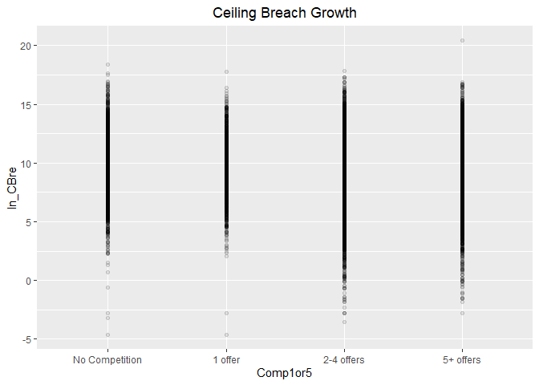

```r
#Scatter Plot
ggplot(serv_smp, aes(x=Comp1or5, y=ln_CBre)) + geom_point(alpha = 0.1) + ggtitle('Ceiling Breach Growth') + theme(plot.title = element_text(hjust = 0.5))
```

```r
#Model
b_CBre05A <- glm (data=serv_smp,
                 b_CBre ~ Comp1or5, family=binomial(link="logit"))
display(b_CBre05A)
```

```
## glm(formula = b_CBre ~ Comp1or5, family = binomial(link = "logit"),
##     data = serv_smp)
##                    coef.est coef.se
## (Intercept)        -3.06     0.02
## Comp1or51 offer    -0.26     0.03
## Comp1or52-4 offers  0.37     0.02
## Comp1or55+ offers   0.57     0.02
## ---
##   n = 250000, k = 4
##   residual deviance = 107298.0, null deviance = 108365.4 (difference = 1067.3)
```

```r
n_CBre05A <- glm(data=serv_smp,
                        ln_CBre ~ Comp1or5)

display(n_CBre05A)
```

```
## glm(formula = ln_CBre ~ Comp1or5, data = serv_smp)
##                    coef.est coef.se
## (Intercept)         9.84     0.05
## Comp1or51 offer    -0.35     0.08
## Comp1or52-4 offers -1.14     0.06
## Comp1or55+ offers  -0.36     0.06
## ---
##   n = 15018, k = 4
##   residual deviance = 111360.8, null deviance = 114568.9 (difference = 3208.1)
##   overdispersion parameter = 7.4
##   residual sd is sqrt(overdispersion) = 2.72
```

```r
#Plot residuals versus fitted
stargazer::stargazer(b_CBre04D,b_CBre05A,

                       n_CBre04D,n_CBre05A,
                       type="text",
                       digits=2)
```

```
##
## ====================================================================
##                                      Dependent variable:
##                          -------------------------------------------
##                                 b_CBre                ln_CBre
##                                logistic               normal
##                             (1)        (2)        (3)        (4)
## --------------------------------------------------------------------
## cl_US6_avg_sal_lag1Const  -0.14***              0.40***
##                            (0.02)                (0.04)
##
## cl_CFTE                   0.09***               0.21***
##                            (0.02)                (0.04)
##
## c_pPBSC                   -0.15***              -0.32***
##                            (0.02)                (0.04)
##
## c_pOffPSC                 0.92***               -0.57***
##                            (0.02)                (0.03)
##
## c_pairHist                -0.15***              0.13***
##                            (0.02)                (0.04)
##
## cl_pairCA                 -0.16***                0.06
##                            (0.02)                (0.05)
##
## cl_Ceil                   0.93***               3.02***
##                            (0.02)                (0.03)
##
## capped_cl_Days              0.02                 0.11**
##                            (0.02)                (0.04)
##
## Comp1or51 offer                      -0.26***              -0.35***
##                                       (0.03)                (0.08)
##
## Comp1or52-4 offers                   0.37***               -1.14***
##                                       (0.02)                (0.06)
##
## Comp1or55+ offers                    0.57***               -0.36***
##                                       (0.02)                (0.06)
##
## Constant                  -2.98***   -3.06***   8.74***    9.84***
##                            (0.01)     (0.02)     (0.02)     (0.05)
##
## --------------------------------------------------------------------
## Observations              250,000    250,000     15,018     15,018
## Log Likelihood           -51,550.71 -53,649.01 -30,485.79 -36,355.09
## Akaike Inf. Crit.        103,119.40 107,306.00 60,989.58  72,718.18
## ====================================================================
## Note:                                    *p<0.1; **p<0.05; ***p<0.01
```

#### 05B: Cumulative Model

```r
#Model
b_CBre05B <- glm (data=serv_smp,
                 b_CBre ~  cl_US6_avg_sal_lag1Const +
                   cl_CFTE+ c_pPBSC+c_pOffPSC+
                 c_pairHist+cl_pairCA +
                   cl_Ceil + capped_cl_Days+
                   Comp1or5, family=binomial(link="logit"))
glmer_examine(b_CBre05B)
```

```
##                              GVIF Df GVIF^(1/(2*Df))
## cl_US6_avg_sal_lag1Const 1.364082  1        1.167939
## cl_CFTE                  1.199378  1        1.095161
## c_pPBSC                  1.283178  1        1.132774
## c_pOffPSC                1.482601  1        1.217621
## c_pairHist               1.244528  1        1.115584
## cl_pairCA                1.566989  1        1.251794
## cl_Ceil                  1.343350  1        1.159030
## capped_cl_Days           1.340681  1        1.157878
## Comp1or5                 1.086522  3        1.013926
```

```r
n_CBre05B <- glm(data=serv_smp,
                        ln_CBre ~  cl_US6_avg_sal_lag1Const +
                   cl_CFTE+ c_pPBSC+c_pOffPSC+
                 c_pairHist+cl_pairCA+
                 cl_Ceil + capped_cl_Days+
                 Comp1or5)

glmer_examine(n_CBre05B)
```

```
##                              GVIF Df GVIF^(1/(2*Df))
## cl_US6_avg_sal_lag1Const 1.332757  1        1.154451
## cl_CFTE                  1.240907  1        1.113960
## c_pPBSC                  2.251506  1        1.500502
## c_pOffPSC                2.852183  1        1.688841
## c_pairHist               1.338107  1        1.156766
## cl_pairCA                2.153209  1        1.467382
## cl_Ceil                  1.724301  1        1.313126
## capped_cl_Days           1.582261  1        1.257880
## Comp1or5                 1.141575  3        1.022314
```

```r
#Plot residuals versus fitted

stargazer::stargazer(b_CBre04D,b_CBre05A,b_CBre05B,

                       n_CBre04D,n_CBre05A,n_CBre05B,
                       type="text",
                       digits=2)
```

```
##
## ==========================================================================================
##                                                 Dependent variable:
##                          -----------------------------------------------------------------
##                                       b_CBre                          ln_CBre
##                                      logistic                          normal
##                             (1)        (2)        (3)        (4)        (5)        (6)
## ------------------------------------------------------------------------------------------
## cl_US6_avg_sal_lag1Const  -0.14***              -0.10***   0.40***               0.39***
##                            (0.02)                (0.02)     (0.04)                (0.04)
##
## cl_CFTE                   0.09***               0.08***    0.21***               0.21***
##                            (0.02)                (0.02)     (0.04)                (0.04)
##
## c_pPBSC                   -0.15***              -0.20***   -0.32***              -0.30***
##                            (0.02)                (0.02)     (0.04)                (0.04)
##
## c_pOffPSC                 0.92***               0.91***    -0.57***              -0.54***
##                            (0.02)                (0.02)     (0.03)                (0.03)
##
## c_pairHist                -0.15***              -0.11***   0.13***               0.11***
##                            (0.02)                (0.02)     (0.04)                (0.04)
##
## cl_pairCA                 -0.16***              -0.21***     0.06                 0.08*
##                            (0.02)                (0.02)     (0.05)                (0.05)
##
## cl_Ceil                   0.93***               0.91***    3.02***               3.04***
##                            (0.02)                (0.02)     (0.03)                (0.03)
##
## capped_cl_Days              0.02                 -0.004     0.11**                0.09**
##                            (0.02)                (0.02)     (0.04)                (0.04)
##
## Comp1or51 offer                      -0.26***   -0.22***              -0.35***    0.10*
##                                       (0.03)     (0.03)                (0.08)     (0.06)
##
## Comp1or52-4 offers                   0.37***    0.30***               -1.14***   -0.21***
##                                       (0.02)     (0.02)                (0.06)     (0.04)
##
## Comp1or55+ offers                    0.57***    0.43***               -0.36***   -0.19***
##                                       (0.02)     (0.03)                (0.06)     (0.04)
##
## Constant                  -2.98***   -3.06***   -3.16***   8.74***    9.84***    8.85***
##                            (0.01)     (0.02)     (0.02)     (0.02)     (0.05)     (0.03)
##
## ------------------------------------------------------------------------------------------
## Observations              250,000    250,000    250,000     15,018     15,018     15,018
## Log Likelihood           -51,550.71 -53,649.01 -51,238.46 -30,485.79 -36,355.09 -30,459.45
## Akaike Inf. Crit.        103,119.40 107,306.00 102,500.90 60,989.58  72,718.18  60,942.90
## ==========================================================================================
## Note:                                                          *p<0.1; **p<0.05; ***p<0.01
```

```r
#summary_residual_compare(b_CBre04D,b_CBre05B)
```

Minimal effect on study variables. 2-4 offers for terminations is not longer significant, it’s really 5+ that boosts the risks. But for exercised options, 5+ leads to more options while fewer having negative relationship with 2-4 offers, but only significant with p-value < 0.1

### Contract Vehicle

#### 06A: Def/Pur; S-IDC; M-IDC; FSS-GWAC; BPA-BOA.

Old text: Expectation: Indefinite delivery vehicles, means that the government has an existing relationship with the vendor and administration is easier. The downside is that the government may be locked into the vendor, although exit does not necessarily require outright termination, instead the government may simply cease to use a vehicle. Taken together, across the board the four categories of vehicles are expected to negatively estimate the probability of termination. Ceiling breaches are a more complex topic and the study team does not have immediate expecations aside from likely significance. Definitive Contract (base) + + + Single-Award IDC - - - Multi-Award IDC - - - FSS/GWAC - - - BPA/BOA - - -

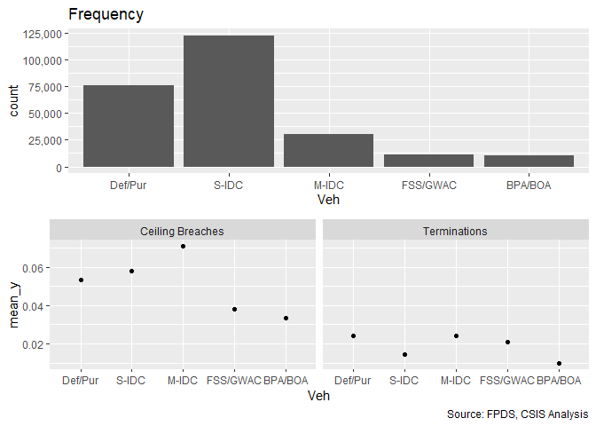

```
## [[1]]
##
##  Def/Pur    S-IDC    M-IDC FSS/GWAC  BPA/BOA
##    75940   122509    29867    11018    10666
##
## [[2]]
##
##              None Ceiling Breach
##   Def/Pur   71876           4064
##   S-IDC    115390           7119
##   M-IDC     27746           2121
##   FSS/GWAC  10600            418
##   BPA/BOA   10307            359
##
## [[3]]
##
##                 0      1
##   Def/Pur   74089   1851
##   S-IDC    120719   1790
##   M-IDC     29140    727
##   FSS/GWAC  10785    233
##   BPA/BOA   10562    104
```

```r
summary_discrete_plot(serv_smp,"Veh")
```

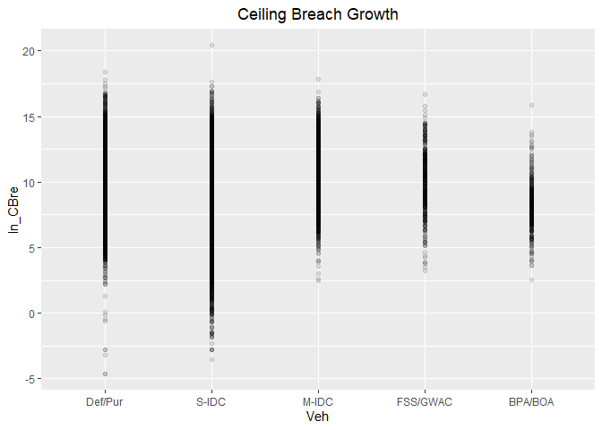

```r
#Scatter Plot
ggplot(serv_smp, aes(x=Veh, y=ln_CBre)) + geom_point(alpha = 0.1) + ggtitle('Ceiling Breach Growth') + theme(plot.title = element_text(hjust = 0.5))
```

```r
#Model
b_CBre06A <- glm (data=serv_smp,
                 b_CBre ~ Veh, family=binomial(link="logit"))
display(b_CBre06A)
```

```
## glm(formula = b_CBre ~ Veh, family = binomial(link = "logit"),
##     data = serv_smp)
##             coef.est coef.se
## (Intercept) -2.87     0.02
## VehS-IDC     0.09     0.02
## VehM-IDC     0.30     0.03
## VehFSS/GWAC -0.36     0.05
## VehBPA/BOA  -0.48     0.06
## ---
##   n = 250000, k = 5
##   residual deviance = 108035.8, null deviance = 108365.4 (difference = 329.5)
```

```r
n_CBre06A <- glm(data=serv_smp,
                        ln_CBre ~ Veh)

display(n_CBre06A)
```

```
## glm(formula = ln_CBre ~ Veh, data = serv_smp)
##             coef.est coef.se
## (Intercept)  9.74     0.04
## VehS-IDC    -1.12     0.05
## VehM-IDC     0.77     0.07
## VehFSS/GWAC  0.30     0.13
## VehBPA/BOA  -1.55     0.14
## ---
##   n = 15018, k = 5
##   residual deviance = 106205.9, null deviance = 114568.9 (difference = 8363.0)
##   overdispersion parameter = 7.1
##   residual sd is sqrt(overdispersion) = 2.66
```

```r
#Plot residuals versus fitted
stargazer::stargazer(b_CBre05B,b_CBre06A,

                       n_CBre05B,n_CBre06A,
                       type="text",
                       digits=2)
```

```
##
## ====================================================================
##                                      Dependent variable:
##                          -------------------------------------------
##                                 b_CBre                ln_CBre
##                                logistic               normal
##                             (1)        (2)        (3)        (4)
## --------------------------------------------------------------------
## cl_US6_avg_sal_lag1Const  -0.10***              0.39***
##                            (0.02)                (0.04)
##
## cl_CFTE                   0.08***               0.21***
##                            (0.02)                (0.04)
##
## c_pPBSC                   -0.20***              -0.30***
##                            (0.02)                (0.04)
##
## c_pOffPSC                 0.91***               -0.54***
##                            (0.02)                (0.03)
##
## c_pairHist                -0.11***              0.11***
##                            (0.02)                (0.04)
##
## cl_pairCA                 -0.21***               0.08*
##                            (0.02)                (0.05)
##
## cl_Ceil                   0.91***               3.04***
##                            (0.02)                (0.03)
##
## capped_cl_Days             -0.004                0.09**
##                            (0.02)                (0.04)
##
## Comp1or51 offer           -0.22***               0.10*
##                            (0.03)                (0.06)
##
## Comp1or52-4 offers        0.30***               -0.21***
##                            (0.02)                (0.04)
##
## Comp1or55+ offers         0.43***               -0.19***
##                            (0.03)                (0.04)
##
## VehS-IDC                             0.09***               -1.12***
##                                       (0.02)                (0.05)
##
## VehM-IDC                             0.30***               0.77***
##                                       (0.03)                (0.07)
##
## VehFSS/GWAC                          -0.36***               0.30**
##                                       (0.05)                (0.13)
##
## VehBPA/BOA                           -0.48***              -1.55***
##                                       (0.06)                (0.14)
##
## Constant                  -3.16***   -2.87***   8.85***    9.74***
##                            (0.02)     (0.02)     (0.03)     (0.04)
##
## --------------------------------------------------------------------
## Observations              250,000    250,000     15,018     15,018
## Log Likelihood           -51,238.46 -54,017.92 -30,459.45 -35,999.20
## Akaike Inf. Crit.        102,500.90 108,045.80 60,942.90  72,008.40
## ====================================================================
## Note:                                    *p<0.1; **p<0.05; ***p<0.01
```

```r
#summary_residual_compare(b_CBre05D,b_CBre06A)
```

For ceiling breaches, IDCs, particularly multiaward IDCs, were more likely to have breaches contrary to expecatitions.

Expectations were largely upheld for options exercised, with the exception of FSS/GWAC.

#### 06B: Cumulative Model

```r
#Model
b_CBre06B <- glm (data=serv_smp,
                 b_CBre ~  cl_US6_avg_sal_lag1Const +
                   cl_CFTE+ c_pPBSC+c_pOffPSC+
                 c_pairHist+cl_pairCA +
                   cl_Ceil + capped_cl_Days+
                   Comp1or5+
                   Veh, family=binomial(link="logit"))
glmer_examine(b_CBre06B)
```

```
##                              GVIF Df GVIF^(1/(2*Df))
## cl_US6_avg_sal_lag1Const 1.390386  1        1.179146
## cl_CFTE                  1.197924  1        1.094497
## c_pPBSC                  1.299089  1        1.139776
## c_pOffPSC                1.513126  1        1.230092
## c_pairHist               1.275647  1        1.129445
## cl_pairCA                1.758946  1        1.326253
## cl_Ceil                  1.389636  1        1.178828
## capped_cl_Days           1.355289  1        1.164169
## Comp1or5                 1.171527  3        1.026736
## Veh                      1.558929  4        1.057069
```

```r
n_CBre06B <- glm(data=serv_smp,
                        ln_CBre ~  cl_US6_avg_sal_lag1Const +
                   cl_CFTE+ c_pPBSC+c_pOffPSC+
                 c_pairHist+cl_pairCA+
                 cl_Ceil + capped_cl_Days+
                 Comp1or5+
                   Veh)

glmer_examine(n_CBre06B)
```

```
##                              GVIF Df GVIF^(1/(2*Df))
## cl_US6_avg_sal_lag1Const 1.382770  1        1.175913
## cl_CFTE                  1.242780  1        1.114801
## c_pPBSC                  2.269828  1        1.506595
## c_pOffPSC                2.927657  1        1.711040
## c_pairHist               1.362077  1        1.167081
## cl_pairCA                2.418552  1        1.555170
## cl_Ceil                  1.786836  1        1.336726
## capped_cl_Days           1.591750  1        1.261646
## Comp1or5                 1.243760  3        1.037025
## Veh                      1.847665  4        1.079762
```

```r
#Plot residuals versus fitted

stargazer::stargazer(b_CBre05B,b_CBre06A,b_CBre06B,

                       n_CBre05B,n_CBre06A,n_CBre06B,
                       type="text",
                       digits=2)
```

```
##
## ==========================================================================================
##                                                 Dependent variable:
##                          -----------------------------------------------------------------
##                                       b_CBre                          ln_CBre
##                                      logistic                          normal
##                             (1)        (2)        (3)        (4)        (5)        (6)
## ------------------------------------------------------------------------------------------
## cl_US6_avg_sal_lag1Const  -0.10***              -0.08***   0.39***               0.35***
##                            (0.02)                (0.02)     (0.04)                (0.04)
##
## cl_CFTE                   0.08***               0.08***    0.21***               0.21***
##                            (0.02)                (0.02)     (0.04)                (0.04)
##
## c_pPBSC                   -0.20***              -0.21***   -0.30***              -0.31***
##                            (0.02)                (0.02)     (0.04)                (0.04)
##
## c_pOffPSC                 0.91***               0.93***    -0.54***              -0.53***
##                            (0.02)                (0.02)     (0.03)                (0.04)
##
## c_pairHist                -0.11***              -0.09***   0.11***               0.10***
##                            (0.02)                (0.02)     (0.04)                (0.04)
##
## cl_pairCA                 -0.21***              -0.17***    0.08*                  0.02
##                            (0.02)                (0.02)     (0.05)                (0.05)
##
## cl_Ceil                   0.91***               0.89***    3.04***               3.05***
##                            (0.02)                (0.02)     (0.03)                (0.04)
##
## capped_cl_Days             -0.004                 0.02      0.09**                0.09*
##                            (0.02)                (0.02)     (0.04)                (0.04)
##
## Comp1or51 offer           -0.22***              -0.20***    0.10*                  0.09
##                            (0.03)                (0.03)     (0.06)                (0.06)
##
## Comp1or52-4 offers        0.30***               0.33***    -0.21***              -0.22***
##                            (0.02)                (0.02)     (0.04)                (0.04)
##
## Comp1or55+ offers         0.43***               0.46***    -0.19***              -0.22***
##                            (0.03)                (0.03)     (0.04)                (0.04)
##
## VehS-IDC                             0.09***    -0.21***              -1.12***   0.17***
##                                       (0.02)     (0.02)                (0.05)     (0.04)
##
## VehM-IDC                             0.30***    -0.17***              0.77***    0.17***
##                                       (0.03)     (0.03)                (0.07)     (0.05)
##
## VehFSS/GWAC                          -0.36***   -0.45***               0.30**    0.29***
##                                       (0.05)     (0.05)                (0.13)     (0.09)
##
## VehBPA/BOA                           -0.48***   -0.44***              -1.55***    0.22**
##                                       (0.06)     (0.06)                (0.14)     (0.10)
##
## Constant                  -3.16***   -2.87***   -3.03***   8.85***    9.74***    8.74***
##                            (0.02)     (0.02)     (0.02)     (0.03)     (0.04)     (0.04)
##
## ------------------------------------------------------------------------------------------
## Observations              250,000    250,000    250,000     15,018     15,018     15,018
## Log Likelihood           -51,238.46 -54,017.92 -51,163.12 -30,459.45 -35,999.20 -30,447.40
## Akaike Inf. Crit.        102,500.90 108,045.80 102,358.20 60,942.90  72,008.40  60,926.80
## ==========================================================================================
## Note:                                                          *p<0.1; **p<0.05; ***p<0.01
```

```r
#summary_residual_compare(b_CBre05B,b_CBre06B)
```

Expectations for vehicle are now upheld for both ceiling breaches and terminations. For other variables the addition of vehicle proved less pivotal, though coefficients were often decreased.

### Type of Contract

The next step adds a measure for whether the contract was cost-based or fixed-price.

Expectation Prior CSIS research has found that fixed-price contracts estimate a higher probability of terminations but did not find a notable relationship for ceiling breaches.

#### 07A: FFP / Other FP / Incentive / T&M/FP:LOE;LH / Other CB / Combination

Firm-Fixed Price (base) + ++ + Other Fixed Price - - - Time & Materials / Labor Hours / FP: LoE + - - Incentive Fee (both FPIF or CBIF) - - + Other Cost Based - - - Undefinitized Contract Award ++ ++ – Combination + + -

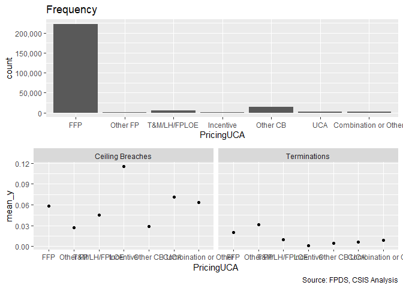

```
## [[1]]
##
##                  FFP             Other FP         T&M/LH/FPLOE
##               222855                 1581                 4696
##            Incentive             Other CB                  UCA
##                  998                14501                 2858
## Combination or Other
##                 2511
##
## [[2]]
##
##                          None Ceiling Breach
##   FFP                  209928          12927
##   Other FP               1538             43
##   T&M/LH/FPLOE           4483            213
##   Incentive               883            115
##   Other CB              14081            420
##   UCA                    2654            204
##   Combination or Other   2352            159
##
## [[3]]
##
##                             0      1
##   FFP                  218357   4498
##   Other FP               1532     49
##   T&M/LH/FPLOE           4650     46
##   Incentive               997      1
##   Other CB              14431     70
##   UCA                    2839     19
##   Combination or Other   2489     22
```

```r
serv_smp$PricingUCA<-factor(serv_smp$PricingUCA,
                            levels=c( "FFP","Other FP","T&M/LH/FPLOE","Incentive","Other CB","UCA" ,"Combination or Other" ))
serv_smp$PricingUCA<-factor(serv_smp$PricingUCA,
                            levels=c( "FFP","Other FP","T&M/LH/FPLOE","Incentive","Other CB","UCA" ,"Combination or Other" ))
  summary_discrete_plot(serv_smp,"PricingUCA")
```

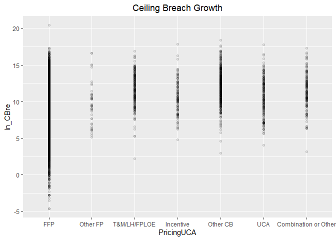

```r
#Scatter Plot
ggplot(serv_smp, aes(x=PricingUCA, y=ln_CBre)) + geom_point(alpha = 0.1) + ggtitle('Ceiling Breach Growth') + theme(plot.title = element_text(hjust = 0.5))
```

```r
#Model
b_CBre07A <- glm (data=serv_smp,
                 b_CBre ~ PricingUCA, family=binomial(link="logit"))
display(b_CBre07A)
```

```
## glm(formula = b_CBre ~ PricingUCA, family = binomial(link = "logit"),
##     data = serv_smp)
##                                coef.est coef.se
## (Intercept)                    -2.79     0.01
## PricingUCAOther FP             -0.79     0.15
## PricingUCAT&M/LH/FPLOE         -0.26     0.07
## PricingUCAIncentive             0.75     0.10
## PricingUCAOther CB             -0.72     0.05
## PricingUCAUCA                   0.22     0.07
## PricingUCACombination or Other  0.09     0.08
## ---
##   n = 250000, k = 7
##   residual deviance = 108000.8, null deviance = 108365.4 (difference = 364.6)
```

```r
n_CBre07A <- glm(data=serv_smp,
                        ln_CBre ~ PricingUCA)
display(n_CBre07A)
```

```
## glm(formula = ln_CBre ~ PricingUCA, data = serv_smp)
##                                coef.est coef.se
## (Intercept)                    9.07     0.02
## PricingUCAOther FP             0.63     0.40
## PricingUCAT&M/LH/FPLOE         2.64     0.18
## PricingUCAIncentive            1.53     0.24
## PricingUCAOther CB             3.01     0.13
## PricingUCAUCA                  1.61     0.19
## PricingUCACombination or Other 2.37     0.21
## ---
##   n = 15018, k = 7
##   residual deviance = 107833.9, null deviance = 114568.9 (difference = 6735.0)
##   overdispersion parameter = 7.2
##   residual sd is sqrt(overdispersion) = 2.68
```

```r
#Plot residuals versus fitted
stargazer::stargazer(b_CBre06B,b_CBre07A,

                       n_CBre06B,n_CBre07A,
                       type="text",
                       digits=2)
```

```
##
## ==========================================================================
##                                            Dependent variable:
##                                -------------------------------------------
##                                       b_CBre                ln_CBre
##                                      logistic               normal
##                                   (1)        (2)        (3)        (4)
## --------------------------------------------------------------------------
## cl_US6_avg_sal_lag1Const        -0.08***              0.35***
##                                  (0.02)                (0.04)
##
## cl_CFTE                         0.08***               0.21***
##                                  (0.02)                (0.04)
##
## c_pPBSC                         -0.21***              -0.31***
##                                  (0.02)                (0.04)
##
## c_pOffPSC                       0.93***               -0.53***
##                                  (0.02)                (0.04)
##
## c_pairHist                      -0.09***              0.10***
##                                  (0.02)                (0.04)
##
## cl_pairCA                       -0.17***                0.02
##                                  (0.02)                (0.05)
##
## cl_Ceil                         0.89***               3.05***
##                                  (0.02)                (0.04)
##
## capped_cl_Days                    0.02                 0.09*
##                                  (0.02)                (0.04)
##
## Comp1or51 offer                 -0.20***                0.09
##                                  (0.03)                (0.06)
##
## Comp1or52-4 offers              0.33***               -0.22***
##                                  (0.02)                (0.04)
##
## Comp1or55+ offers               0.46***               -0.22***
##                                  (0.03)                (0.04)
```

[output cut: 25 more lines]

```
## PricingUCAUCA                              0.22***               1.61***
##                                             (0.07)                (0.19)
##
## PricingUCACombination or Other               0.09                2.37***
##                                             (0.08)                (0.21)
##
## Constant                        -3.03***   -2.79***   8.74***    9.07***
##                                  (0.02)     (0.01)     (0.04)     (0.02)
##
## --------------------------------------------------------------------------
## Observations                    250,000    250,000     15,018     15,018
## Log Likelihood                 -51,163.12 -54,000.40 -30,447.40 -36,113.43
## Akaike Inf. Crit.              102,358.20 108,014.80 60,926.80  72,240.86
## ==========================================================================
## Note:                                          *p<0.1; **p<0.05; ***p<0.01
```

```r
#summary_residual_compare(b_CBre06B,b_CBre07A,30)
```

#### 07B: Cumulative Model

```r
#Model
b_CBre07B <- glm (data=serv_smp,
                 b_CBre ~  cl_US6_avg_sal_lag1Const +
                   cl_CFTE+ c_pPBSC+c_pOffPSC+
                 c_pairHist+cl_pairCA +
                   cl_Ceil + capped_cl_Days+
                   Comp1or5+
                   Veh+
                   PricingUCA, family=binomial(link="logit"))
glmer_examine(b_CBre07B)
```

```
##                              GVIF Df GVIF^(1/(2*Df))
## cl_US6_avg_sal_lag1Const 1.360105  1        1.166235
## cl_CFTE                  1.189973  1        1.090859
## c_pPBSC                  1.321147  1        1.149412
## c_pOffPSC                1.535437  1        1.239127
## c_pairHist               1.260898  1        1.122897
## cl_pairCA                1.745244  1        1.321077
## cl_Ceil                  1.408770  1        1.186916
## capped_cl_Days           1.351091  1        1.162364
## Comp1or5                 1.215664  3        1.033084
## Veh                      1.566437  4        1.057704
## PricingUCA               1.147597  6        1.011539
```

```r
n_CBre07B <- glm(data=serv_smp,
                        ln_CBre ~  cl_US6_avg_sal_lag1Const +
                   cl_CFTE+ c_pPBSC+c_pOffPSC+
                 c_pairHist+cl_pairCA+
                 cl_Ceil + capped_cl_Days+
                 Comp1or5+
                   Veh+
                   PricingUCA)

glmer_examine(n_CBre07B)
```

```
##                              GVIF Df GVIF^(1/(2*Df))
## cl_US6_avg_sal_lag1Const 1.391434  1        1.179591
## cl_CFTE                  1.247020  1        1.116701
## c_pPBSC                  2.278101  1        1.509338
## c_pOffPSC                2.943244  1        1.715589
## c_pairHist               1.370470  1        1.170671
## cl_pairCA                2.466143  1        1.570396
## cl_Ceil                  1.844320  1        1.358058
## capped_cl_Days           1.600166  1        1.264977
## Comp1or5                 1.275476  3        1.041387
## Veh                      1.889030  4        1.082754
## PricingUCA               1.187003  6        1.014389
```

```r
#Plot residuals versus fitted

stargazer::stargazer(b_CBre06B,b_CBre07A,b_CBre07B,

                       n_CBre06B,n_CBre07A,n_CBre07B,
                       type="text",
                       digits=2)
```

```
##
## ================================================================================================
##                                                       Dependent variable:
##                                -----------------------------------------------------------------
##                                             b_CBre                          ln_CBre
##                                            logistic                          normal
##                                   (1)        (2)        (3)        (4)        (5)        (6)
## ------------------------------------------------------------------------------------------------
## cl_US6_avg_sal_lag1Const        -0.08***               -0.03     0.35***               0.29***
##                                  (0.02)                (0.02)     (0.04)                (0.04)
##
## cl_CFTE                         0.08***               0.11***    0.21***               0.20***
##                                  (0.02)                (0.02)     (0.04)                (0.04)
##
## c_pPBSC                         -0.21***              -0.19***   -0.31***              -0.34***
##                                  (0.02)                (0.02)     (0.04)                (0.04)
##
## c_pOffPSC                       0.93***               0.94***    -0.53***              -0.50***
##                                  (0.02)                (0.02)     (0.04)                (0.03)
##
## c_pairHist                      -0.09***              -0.07***   0.10***               0.09***
##                                  (0.02)                (0.02)     (0.04)                (0.04)
##
## cl_pairCA                       -0.17***              -0.12***     0.02                 -0.10*
##                                  (0.02)                (0.02)     (0.05)                (0.05)
##
## cl_Ceil                         0.89***               0.97***    3.05***               2.94***
##                                  (0.02)                (0.02)     (0.04)                (0.04)
##
## capped_cl_Days                    0.02                0.08***     0.09*                  0.03
##                                  (0.02)                (0.02)     (0.04)                (0.04)
##
## Comp1or51 offer                 -0.20***              -0.18***     0.09                  0.05
##                                  (0.03)                (0.03)     (0.06)                (0.06)
##
## Comp1or52-4 offers              0.33***               0.31***    -0.22***              -0.22***
##                                  (0.02)                (0.02)     (0.04)                (0.04)
##
## Comp1or55+ offers               0.46***               0.37***    -0.22***              -0.14***
##                                  (0.03)                (0.03)     (0.04)                (0.04)
```

[output cut: 25 more lines]

```
## PricingUCAUCA                              0.22***      0.01                1.61***    0.59***
##                                             (0.07)     (0.08)                (0.19)     (0.13)
##
## PricingUCACombination or Other               0.09     -0.41***              2.37***    0.76***
##                                             (0.08)     (0.08)                (0.21)     (0.14)
##
## Constant                        -3.03***   -2.79***   -2.97***   8.74***    9.07***    8.69***
##                                  (0.02)     (0.01)     (0.02)     (0.04)     (0.02)     (0.04)
##
## ------------------------------------------------------------------------------------------------
## Observations                    250,000    250,000    250,000     15,018     15,018     15,018
## Log Likelihood                 -51,163.12 -54,000.40 -50,769.53 -30,447.40 -36,113.43 -30,266.56
## Akaike Inf. Crit.              102,358.20 108,014.80 101,583.10 60,926.80  72,240.86  60,577.13
## ================================================================================================
## Note:                                                                *p<0.1; **p<0.05; ***p<0.01
```

```r
#summary_residual_compare(b_CBre06B,b_CBre07B)
#summary_residual_compare(b_CBre07A,b_CBre07B,bins=3)
```

### Crisis Dataset

Expectation: Service Contract replying on crisis funds would have more likelihood of cost-ceiling breaches and exercised options but less terminations.

#### 08A: Crisis Funding

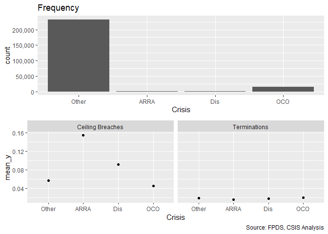

```
## [[1]]
##
##  Other   ARRA    Dis    OCO
## 233251   1504    404  14841
##
## [[2]]
##
##           None Ceiling Breach
##   Other 220097          13154
##   ARRA    1272            232
##   Dis      367             37
##   OCO    14183            658
##
## [[3]]
##
##              0      1
##   Other 228867   4384
##   ARRA    1481     23
##   Dis      397      7
##   OCO    14550    291
```

```r
summary_discrete_plot(serv_smp,"Crisis")
```

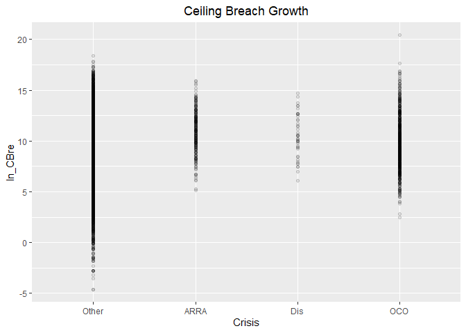

```r
#Scatter Plot
ggplot(serv_smp, aes(x=Crisis, y=ln_CBre)) + geom_point(alpha = 0.1) + ggtitle('Ceiling Breach Growth') + theme(plot.title = element_text(hjust = 0.5))
```

```r
#Model
b_CBre08A <- glm (data=serv_smp,
                 b_CBre ~ Crisis, family=binomial(link="logit"))
display(b_CBre08A)
```

```
## glm(formula = b_CBre ~ Crisis, family = binomial(link = "logit"),
##     data = serv_smp)
##             coef.est coef.se
## (Intercept) -2.82     0.01
## CrisisARRA   1.12     0.07
## CrisisDis    0.52     0.17
## CrisisOCO   -0.25     0.04
## ---
##   n = 250000, k = 4
##   residual deviance = 108125.4, null deviance = 108365.4 (difference = 239.9)
```

```r
n_CBre08A <- glm(data=serv_smp,
                        ln_CBre ~ Crisis)

display(n_CBre08A)
```

```
## glm(formula = ln_CBre ~ Crisis, data = serv_smp)
##             coef.est coef.se
## (Intercept) 9.20     0.02
## CrisisARRA  1.77     0.18
## CrisisDis   1.34     0.42
## CrisisOCO   0.57     0.11
## ---
##   n = 15018, k = 4
##   residual deviance = 113551.4, null deviance = 114568.9 (difference = 1017.4)
##   overdispersion parameter = 7.6
##   residual sd is sqrt(overdispersion) = 2.75
```

```r
#Plot residuals versus fitted
stargazer::stargazer(b_CBre07B,b_CBre08A,

                       n_CBre07B,n_CBre08A,
                       type="text",
                       digits=2)
```

```
##
## ==========================================================================
##                                            Dependent variable:
##                                -------------------------------------------
##                                       b_CBre                ln_CBre
##                                      logistic               normal
##                                   (1)        (2)        (3)        (4)
## --------------------------------------------------------------------------
## cl_US6_avg_sal_lag1Const         -0.03                0.29***
##                                  (0.02)                (0.04)
##
## cl_CFTE                         0.11***               0.20***
##                                  (0.02)                (0.04)
##
## c_pPBSC                         -0.19***              -0.34***
##                                  (0.02)                (0.04)
##
## c_pOffPSC                       0.94***               -0.50***
##                                  (0.02)                (0.03)
##
## c_pairHist                      -0.07***              0.09***
##                                  (0.02)                (0.04)
##
## cl_pairCA                       -0.12***               -0.10*
##                                  (0.02)                (0.05)
##
## cl_Ceil                         0.97***               2.94***
##                                  (0.02)                (0.04)
##
## capped_cl_Days                  0.08***                 0.03
##                                  (0.02)                (0.04)
##
## Comp1or51 offer                 -0.18***                0.05
##                                  (0.03)                (0.06)
##
## Comp1or52-4 offers              0.31***               -0.22***
##                                  (0.02)                (0.04)
##
## Comp1or55+ offers               0.37***               -0.14***
##                                  (0.03)                (0.04)
```

[output cut: 34 more lines]

```
## CrisisDis                                  0.52***               1.34***
##                                             (0.17)                (0.42)
##
## CrisisOCO                                  -0.25***              0.57***
##                                             (0.04)                (0.11)
##
## Constant                        -2.97***   -2.82***   8.69***    9.20***
##                                  (0.02)     (0.01)     (0.04)     (0.02)
##
## --------------------------------------------------------------------------
## Observations                    250,000    250,000     15,018     15,018
## Log Likelihood                 -50,769.53 -54,062.72 -30,266.56 -36,501.38
## Akaike Inf. Crit.              101,583.10 108,133.40 60,577.13  73,010.75
## ==========================================================================
## Note:                                          *p<0.1; **p<0.05; ***p<0.01
```

```r
# summary_residual_compare(b_CBre07B,b_CBre08A,30)
```

For ceiling breaches ARRA and Disaster results were in keeping with expcetations but OCO results were not. There were no significant results for terminations. For options, contrary to exepectation, all forms of crisis funding have a lower rate of usage.

#### 08B: Cumulative Model

```r
#Model
b_CBre08B <- glm (data=serv_smp,
                 b_CBre ~  cl_US6_avg_sal_lag1Const +
                   cl_CFTE+ c_pPBSC+c_pOffPSC+
                 c_pairHist+cl_pairCA +
                   cl_Ceil + capped_cl_Days+
                   Comp1or5+
                   Veh+
                   PricingUCA+
                   Crisis, family=binomial(link="logit"))
glmer_examine(b_CBre08B)
```

```
##                              GVIF Df GVIF^(1/(2*Df))
## cl_US6_avg_sal_lag1Const 1.395808  1        1.181443
## cl_CFTE                  1.312641  1        1.145705
## c_pPBSC                  1.330137  1        1.153316
## c_pOffPSC                1.573596  1        1.254431
## c_pairHist               1.264214  1        1.124373
## cl_pairCA                1.934959  1        1.391028
## cl_Ceil                  1.450743  1        1.204468
## capped_cl_Days           1.391141  1        1.179466
## Comp1or5                 1.229120  3        1.034981
## Veh                      1.679690  4        1.066974
## PricingUCA               1.153694  6        1.011985
## Crisis                   1.347664  3        1.050986
```

```r
n_CBre08B <- glm(data=serv_smp,
                        ln_CBre ~  cl_US6_avg_sal_lag1Const +
                   cl_CFTE+ c_pPBSC+c_pOffPSC+
                 c_pairHist+cl_pairCA+
                 cl_Ceil + capped_cl_Days+
                 Comp1or5+
                   Veh+
                   PricingUCA+
                   Crisis)
glmer_examine(n_CBre08B)
```

```
##                              GVIF Df GVIF^(1/(2*Df))
## cl_US6_avg_sal_lag1Const 1.404644  1        1.185177
## cl_CFTE                  1.362846  1        1.167410
## c_pPBSC                  2.298956  1        1.516231
## c_pOffPSC                2.951405  1        1.717965
## c_pairHist               1.371021  1        1.170906
## cl_pairCA                2.511014  1        1.584618
## cl_Ceil                  1.862581  1        1.364764
## capped_cl_Days           1.612362  1        1.269788
## Comp1or5                 1.280984  3        1.042135
## Veh                      1.976792  4        1.088918
## PricingUCA               1.192715  6        1.014794
## Crisis                   1.206807  3        1.031826
```

```r
#Plot residuals versus fitted

stargazer::stargazer(b_CBre07B,b_CBre08A,b_CBre08B,

                       n_CBre07B,n_CBre08A,n_CBre08B,
                       type="text",
                       digits=2)
```

```
##
## ================================================================================================
##                                                       Dependent variable:
##                                -----------------------------------------------------------------
##                                             b_CBre                          ln_CBre
##                                            logistic                          normal
##                                   (1)        (2)        (3)        (4)        (5)        (6)
## ------------------------------------------------------------------------------------------------
## cl_US6_avg_sal_lag1Const         -0.03                 -0.01     0.29***               0.26***
##                                  (0.02)                (0.02)     (0.04)                (0.04)
##
## cl_CFTE                         0.11***               0.07***    0.20***               0.28***
##                                  (0.02)                (0.02)     (0.04)                (0.04)
##
## c_pPBSC                         -0.19***              -0.18***   -0.34***              -0.32***
##                                  (0.02)                (0.02)     (0.04)                (0.04)
##
## c_pOffPSC                       0.94***               0.92***    -0.50***              -0.49***
##                                  (0.02)                (0.02)     (0.03)                (0.03)
##
## c_pairHist                      -0.07***              -0.07***   0.09***               0.10***
##                                  (0.02)                (0.02)     (0.04)                (0.04)
##
## cl_pairCA                       -0.12***              -0.08***    -0.10*               -0.15***
##                                  (0.02)                (0.02)     (0.05)                (0.05)
##
## cl_Ceil                         0.97***               0.97***    2.94***               2.92***
##                                  (0.02)                (0.02)     (0.04)                (0.04)
##
## capped_cl_Days                  0.08***                0.06**      0.03                  0.06
##                                  (0.02)                (0.02)     (0.04)                (0.04)
##
## Comp1or51 offer                 -0.18***              -0.16***     0.05                  0.04
##                                  (0.03)                (0.03)     (0.06)                (0.06)
##
## Comp1or52-4 offers              0.31***               0.31***    -0.22***              -0.24***
##                                  (0.02)                (0.02)     (0.04)                (0.04)
##
## Comp1or55+ offers               0.37***               0.38***    -0.14***              -0.15***
##                                  (0.03)                (0.03)     (0.04)                (0.04)
```

[output cut: 34 more lines]

```
## CrisisDis                                  0.52***     0.40**               1.34***      0.37
##                                             (0.17)     (0.18)                (0.42)     (0.28)
##
## CrisisOCO                                  -0.25***   -0.25***              0.57***    0.57***
##                                             (0.04)     (0.05)                (0.11)     (0.08)
##
## Constant                        -2.97***   -2.82***   -2.95***   8.69***    9.20***    8.65***
##                                  (0.02)     (0.01)     (0.02)     (0.04)     (0.02)     (0.04)
##
## ------------------------------------------------------------------------------------------------
## Observations                    250,000    250,000    250,000     15,018     15,018     15,018
## Log Likelihood                 -50,769.53 -54,062.72 -50,713.94 -30,266.56 -36,501.38 -30,237.41
## Akaike Inf. Crit.              101,583.10 108,133.40 101,477.90 60,577.13  73,010.75  60,524.83
## ================================================================================================
## Note:                                                                *p<0.1; **p<0.05; ***p<0.01
```

```r
#summary_residual_compare(b_CBre07B,b_CBre08B)
```

Terminatins for OCO and ARRA are now significant in the expected direction.

## Industrial Sector

### Level 6

#### Model 09A: l_def6_HHI_lag1

HHI (logged, + means more consolidation) cl_def6_HHI_lag1+ + - -

Expectations are unchanged.

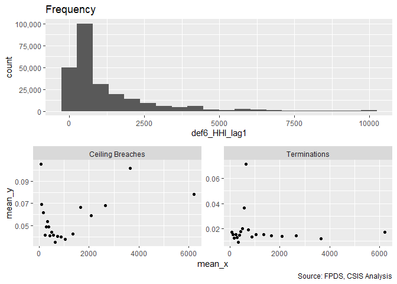

```r
#Frequency Plot for unlogged ceiling
summary_continuous_plot(serv_smp,"def6_HHI_lag1")
```

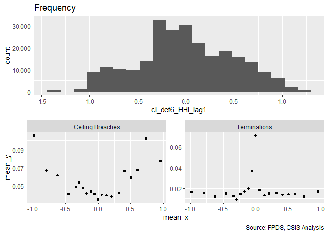

```r
summary_continuous_plot(serv_smp,"cl_def6_HHI_lag1")
```

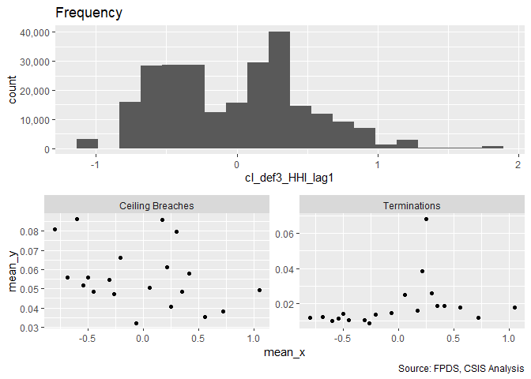

```r
summary_continuous_plot(serv_smp,"cl_def3_HHI_lag1")
```

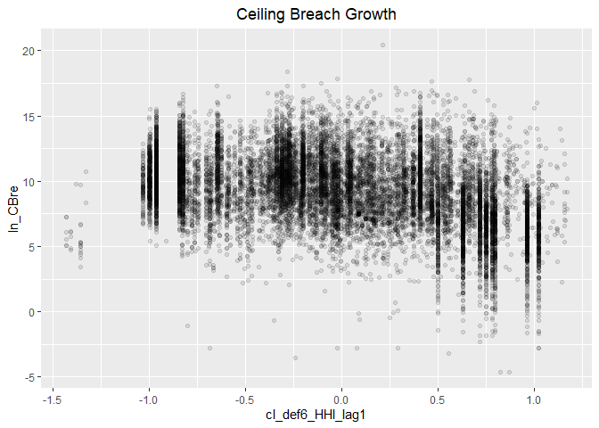

```r
#Scatter Plot
ggplot(serv_smp, aes(x=cl_def6_HHI_lag1, y=ln_CBre)) + geom_point(alpha = 0.1) + ggtitle('Ceiling Breach Growth') + theme(plot.title = element_text(hjust = 0.5))
```

```r
#Model
b_CBre09A <- glm (data=serv_smp,
                 b_CBre ~ cl_def6_HHI_lag1, family=binomial(link="logit"))
display(b_CBre09A)
```

```
## glm(formula = b_CBre ~ cl_def6_HHI_lag1, family = binomial(link = "logit"),
##     data = serv_smp)
##                  coef.est coef.se
## (Intercept)      -2.82     0.01
## cl_def6_HHI_lag1  0.05     0.02
## ---
##   n = 250000, k = 2
##   residual deviance = 108356.8, null deviance = 108365.4 (difference = 8.6)
```

```r
n_CBre09A <- glm(data=serv_smp,
                        ln_CBre ~ cl_def6_HHI_lag1)

display(n_CBre09A)
```

```
## glm(formula = ln_CBre ~ cl_def6_HHI_lag1, data = serv_smp)
##                  coef.est coef.se
## (Intercept)       9.28     0.02
## cl_def6_HHI_lag1 -1.80     0.04
## ---
##   n = 15018, k = 2
##   residual deviance = 98081.9, null deviance = 114568.9 (difference = 16486.9)
##   overdispersion parameter = 6.5
##   residual sd is sqrt(overdispersion) = 2.56
```

```r
#Plot residuals versus fitted
stargazer::stargazer(b_CBre08B,b_CBre09A,

                       n_CBre08B,n_CBre09A,
                       type="text",
                       digits=2)
```

```
##
## ==========================================================================
##                                            Dependent variable:
##                                -------------------------------------------
##                                       b_CBre                ln_CBre
##                                      logistic               normal
##                                   (1)        (2)        (3)        (4)
## --------------------------------------------------------------------------
## cl_US6_avg_sal_lag1Const         -0.01                0.26***
##                                  (0.02)                (0.04)
##
## cl_CFTE                         0.07***               0.28***
##                                  (0.02)                (0.04)
##
## c_pPBSC                         -0.18***              -0.32***
##                                  (0.02)                (0.04)
##
## c_pOffPSC                       0.92***               -0.49***
##                                  (0.02)                (0.03)
##
## c_pairHist                      -0.07***              0.10***
##                                  (0.02)                (0.04)
##
## cl_pairCA                       -0.08***              -0.15***
##                                  (0.02)                (0.05)
##
## cl_Ceil                         0.97***               2.92***
##                                  (0.02)                (0.04)
##
## capped_cl_Days                   0.06**                 0.06
##                                  (0.02)                (0.04)
##
## Comp1or51 offer                 -0.16***                0.04
##                                  (0.03)                (0.06)
##
## Comp1or52-4 offers              0.31***               -0.24***
##                                  (0.02)                (0.04)
##
## Comp1or55+ offers               0.38***               -0.15***
##                                  (0.03)                (0.04)
```

[output cut: 37 more lines]

```
## CrisisOCO                       -0.25***              0.57***
##                                  (0.05)                (0.08)
##
## cl_def6_HHI_lag1                           0.05***               -1.80***
##                                             (0.02)                (0.04)
##
## Constant                        -2.95***   -2.82***   8.65***    9.28***
##                                  (0.02)     (0.01)     (0.04)     (0.02)
##
## --------------------------------------------------------------------------
## Observations                    250,000    250,000     15,018     15,018
## Log Likelihood                 -50,713.94 -54,178.40 -30,237.41 -35,401.66
## Akaike Inf. Crit.              101,477.90 108,360.80 60,524.83  70,807.32
## ==========================================================================
## Note:                                          *p<0.1; **p<0.05; ***p<0.01
```

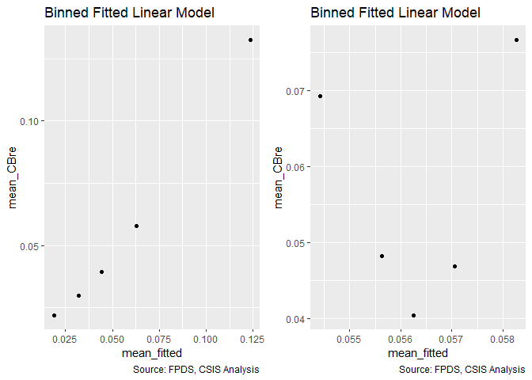

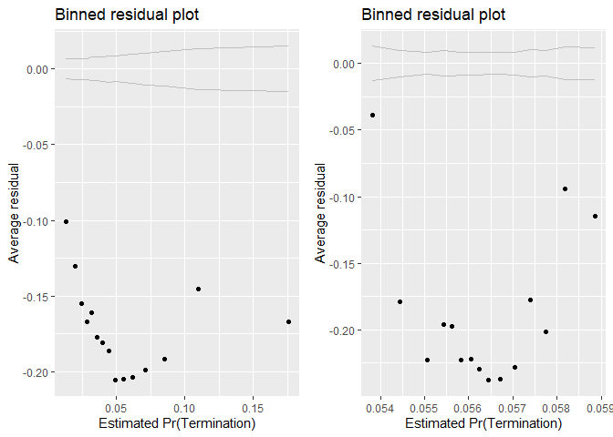

```r
summary_residual_compare(b_CBre08B,b_CBre09A, skip_vif = TRUE)
```

Expected direction for ceiling breach and termination, but no real results on options.

#### Model 09B: Defense to Overall ratio

The higher the ratio of defense obligations to reciepts in the overall economy, the DoD holds a monosopy over a sector. Given the challenges of monosopy, the a higher ratio estimates a greater risk of ceiling breaches.

Ratio Def. obligatons : US revenue cl_def6_obl_lag1+ + - -

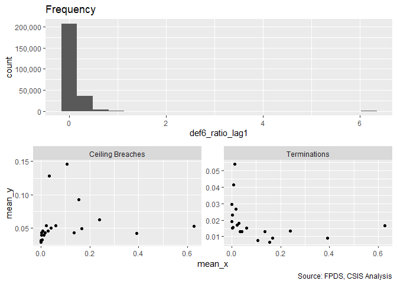

```r
#Frequency Plot for unlogged ceiling
      summary_continuous_plot(serv_smp,"def6_ratio_lag1")
```

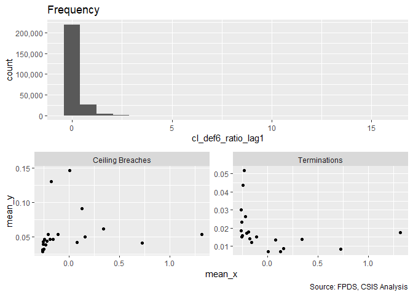

```r
      summary_continuous_plot(serv_smp,"cl_def6_ratio_lag1")
```

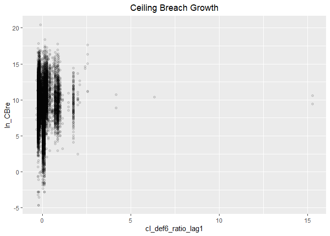

```r
#Scatter Plot
ggplot(serv_smp, aes(x=cl_def6_ratio_lag1, y=ln_CBre)) + geom_point(alpha = 0.1) + ggtitle('Ceiling Breach Growth') + theme(plot.title = element_text(hjust = 0.5))
```

```r
#Model
b_CBre09B <- glm (data=serv_smp,
                 b_CBre ~ cl_def6_ratio_lag1, family=binomial(link="logit"))
display(b_CBre09B)
```

```
## glm(formula = b_CBre ~ cl_def6_ratio_lag1, family = binomial(link = "logit"),
##     data = serv_smp)
##                    coef.est coef.se
## (Intercept)        -2.82     0.01
## cl_def6_ratio_lag1  0.03     0.02
## ---
##   n = 250000, k = 2
##   residual deviance = 108362.8, null deviance = 108365.4 (difference = 2.5)
```

```r
n_CBre09B <- glm(data=serv_smp,
                        ln_CBre ~ cl_def6_ratio_lag1)

display(n_CBre09B)
```

```
## glm(formula = ln_CBre ~ cl_def6_ratio_lag1, data = serv_smp)
##                    coef.est coef.se
## (Intercept)        9.25     0.02
## cl_def6_ratio_lag1 0.26     0.06
## ---
##   n = 15018, k = 2
##   residual deviance = 114410.7, null deviance = 114568.9 (difference = 158.2)
##   overdispersion parameter = 7.6
##   residual sd is sqrt(overdispersion) = 2.76
```

```r
#Plot residuals versus fitted
stargazer::stargazer(b_CBre08B,b_CBre09A,b_CBre09B,

                       n_CBre08B,n_CBre09A,n_CBre09B,
                       type="text",
                       digits=2)
```

```
##
## ================================================================================================
##                                                       Dependent variable:
##                                -----------------------------------------------------------------
##                                             b_CBre                          ln_CBre
##                                            logistic                          normal
##                                   (1)        (2)        (3)        (4)        (5)        (6)
## ------------------------------------------------------------------------------------------------
## cl_US6_avg_sal_lag1Const         -0.01                           0.26***
##                                  (0.02)                           (0.04)
##
## cl_CFTE                         0.07***                          0.28***
##                                  (0.02)                           (0.04)
##
## c_pPBSC                         -0.18***                         -0.32***
##                                  (0.02)                           (0.04)
##
## c_pOffPSC                       0.92***                          -0.49***
##                                  (0.02)                           (0.03)
##
## c_pairHist                      -0.07***                         0.10***
##                                  (0.02)                           (0.04)
##
## cl_pairCA                       -0.08***                         -0.15***
##                                  (0.02)                           (0.05)
##
## cl_Ceil                         0.97***                          2.92***
##                                  (0.02)                           (0.04)
##
## capped_cl_Days                   0.06**                            0.06
##                                  (0.02)                           (0.04)
##
## Comp1or51 offer                 -0.16***                           0.04
##                                  (0.03)                           (0.06)
##
## Comp1or52-4 offers              0.31***                          -0.24***
##                                  (0.02)                           (0.04)
##
## Comp1or55+ offers               0.38***                          -0.15***
##                                  (0.03)                           (0.04)
```

[output cut: 40 more lines]

```
## cl_def6_HHI_lag1                           0.05***                          -1.80***
##                                             (0.02)                           (0.04)
##
## cl_def6_ratio_lag1                                      0.03                           0.26***
##                                                        (0.02)                           (0.06)
##
## Constant                        -2.95***   -2.82***   -2.82***   8.65***    9.28***    9.25***
##                                  (0.02)     (0.01)     (0.01)     (0.04)     (0.02)     (0.02)
##
## ------------------------------------------------------------------------------------------------
## Observations                    250,000    250,000    250,000     15,018     15,018     15,018
## Log Likelihood                 -50,713.94 -54,178.40 -54,181.42 -30,237.41 -35,401.66 -36,557.98
## Akaike Inf. Crit.              101,477.90 108,360.80 108,366.80 60,524.83  70,807.32  73,119.97
## ================================================================================================
## Note:                                                                *p<0.1; **p<0.05; ***p<0.01
```

```r
#summary_residual_compare(b_CBre08B,b_CBre09B)
#summary_residual_compare(b_CBre09A,b_CBre09B)
```

#### Model 09C: Defense Obligations

Defense obligations (logged) cl_def6_ratio_lag1+ - - +

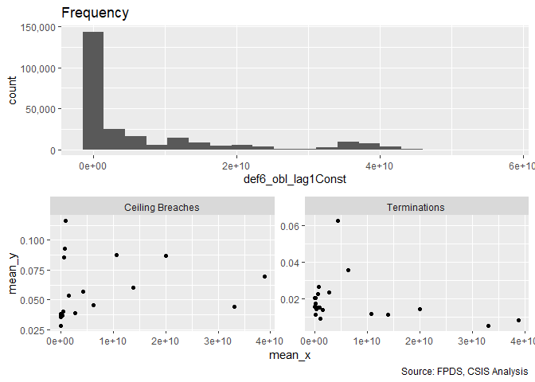

```r
#Frequency Plot for unlogged ceiling
      summary_continuous_plot(serv_smp,"def6_obl_lag1Const")
```

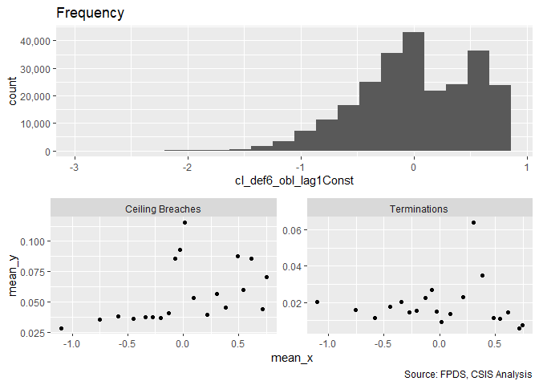

```r
      summary_continuous_plot(serv_smp,"cl_def6_obl_lag1Const")
```

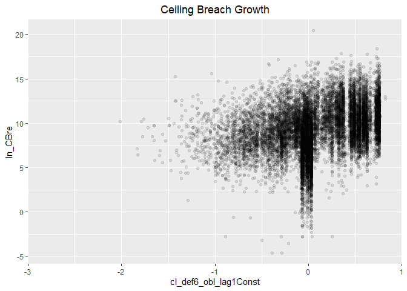

```r
#Scatter Plot
ggplot(serv_smp, aes(x=cl_def6_obl_lag1Const, y=ln_CBre)) + geom_point(alpha = 0.1) + ggtitle('Ceiling Breach Growth') + theme(plot.title = element_text(hjust = 0.5))
```

```r
#Model
b_CBre09C <- glm (data=serv_smp,
                 b_CBre ~ cl_def6_obl_lag1Const, family=binomial(link="logit"))
display(b_CBre09C)
```

```
## glm(formula = b_CBre ~ cl_def6_obl_lag1Const, family = binomial(link = "logit"),
##     data = serv_smp)
##                       coef.est coef.se
## (Intercept)           -2.84     0.01
## cl_def6_obl_lag1Const  0.45     0.02
## ---
##   n = 250000, k = 2
##   residual deviance = 107741.4, null deviance = 108365.4 (difference = 624.0)
```

```r
n_CBre09C <- glm(data=serv_smp,
                        ln_CBre ~ cl_def6_obl_lag1Const)

display(n_CBre09C)
```

```
## glm(formula = ln_CBre ~ cl_def6_obl_lag1Const, data = serv_smp)
##                       coef.est coef.se
## (Intercept)           9.05     0.02
## cl_def6_obl_lag1Const 2.00     0.05
## ---
##   n = 15018, k = 2
##   residual deviance = 103002.7, null deviance = 114568.9 (difference = 11566.2)
##   overdispersion parameter = 6.9
##   residual sd is sqrt(overdispersion) = 2.62
```

```r
#Plot residuals versus fitted
stargazer::stargazer(b_CBre09A,b_CBre09B,b_CBre09C,

                       n_CBre09A,n_CBre09B,n_CBre09C,
                       type="text",
                       digits=2)
```

```
##
## =======================================================================================
##                                              Dependent variable:
##                       -----------------------------------------------------------------
##                                    b_CBre                          ln_CBre
##                                   logistic                          normal
##                          (1)        (2)        (3)        (4)        (5)        (6)
## ---------------------------------------------------------------------------------------
## cl_def6_HHI_lag1       0.05***                          -1.80***
##                         (0.02)                           (0.04)
##
## cl_def6_ratio_lag1                  0.03                           0.26***
##                                    (0.02)                           (0.06)
##
## cl_def6_obl_lag1Const                        0.45***                          2.00***
##                                               (0.02)                           (0.05)
##
## Constant               -2.82***   -2.82***   -2.84***   9.28***    9.25***    9.05***
##                         (0.01)     (0.01)     (0.01)     (0.02)     (0.02)     (0.02)
##
## ---------------------------------------------------------------------------------------
## Observations           250,000    250,000    250,000     15,018     15,018     15,018
## Log Likelihood        -54,178.40 -54,181.42 -53,870.68 -35,401.66 -36,557.98 -35,769.24
## Akaike Inf. Crit.     108,360.80 108,366.80 107,745.40 70,807.32  73,119.97  71,542.48
## =======================================================================================
## Note:                                                       *p<0.1; **p<0.05; ***p<0.01
```

```r
#summary_residual_compare(b_CBre08B,b_CBre09C)
#summary_residual_compare(b_CBre09A,b_CBre09C)
#summary_residual_compare(b_CBre09B,b_CBre09C)
```

Contrary to expectation. for termination and options.

#### Model 09D: NAICS 6 Combined

Consolidation at lessa nd more granular levels may have different effects. Efficiencies are often used to describe sectors, like utilities, with high barriers to entry. Many of these aspects seem like they would already be captured at less granular NAICS levels, e.g. power plants, rather than more specific NAICS levels, like solar vs. coal. As a result, consolidation for more granular NAICS codes should estimate higher rates of ceiling breaches compared to less granular NAICS code.

We’ll start by adding in everything from both models and seeing what violates VIF.

```r
#Frequency Plot for unlogged ceiling



#Model
b_CBre09D <- glm (data=serv_smp,
                 b_CBre ~ cl_def6_HHI_lag1+cl_def6_ratio_lag1+cl_def6_obl_lag1Const
                 , family=binomial(link="logit"))
glmer_examine(b_CBre09D)
```

```
##      cl_def6_HHI_lag1    cl_def6_ratio_lag1 cl_def6_obl_lag1Const
##              1.246031              1.523134              1.510329
```

```r
n_CBre09D <- glm(data=serv_smp,
                        ln_CBre ~ cl_def6_HHI_lag1+cl_def6_ratio_lag1)

glmer_examine(n_CBre09D)
```

```
##   cl_def6_HHI_lag1 cl_def6_ratio_lag1
##           1.065104           1.065104
```

```r
b_CBre09D2 <- glm (data=serv_smp,
                 b_CBre ~ cl_def6_HHI_lag1+cl_def6_ratio_lag1
                 , family=binomial(link="logit"))
glmer_examine(b_CBre09D2)
```

```
##   cl_def6_HHI_lag1 cl_def6_ratio_lag1
##           1.049186           1.049186
```

```r
n_CBre09D2 <- glm(data=serv_smp,
                        ln_CBre ~ cl_def6_HHI_lag1+cl_def6_ratio_lag1)

glmer_examine(n_CBre09D2)
```

```
##   cl_def6_HHI_lag1 cl_def6_ratio_lag1
##           1.065104           1.065104
```

```r
#Plot residuals versus fitted
stargazer::stargazer(b_CBre09D,b_CBre09D2,

                     n_CBre09D,n_CBre09D2,
                       type="text",
                       digits=2)
```

```
##
## =================================================================
##                                   Dependent variable:
##                       -------------------------------------------
##                              b_CBre                ln_CBre
##                             logistic               normal
##                          (1)        (2)        (3)        (4)
## -----------------------------------------------------------------
## cl_def6_HHI_lag1       0.26***    0.05***    -1.96***   -1.96***
##                         (0.02)     (0.02)     (0.04)     (0.04)
##
## cl_def6_ratio_lag1     -0.39***     0.02     0.98***    0.98***
##                         (0.03)     (0.02)     (0.05)     (0.05)
##
## cl_def6_obl_lag1Const  0.66***
##                         (0.02)
##
## Constant               -2.86***   -2.82***   9.28***    9.28***
##                         (0.01)     (0.01)     (0.02)     (0.02)
##
## -----------------------------------------------------------------
## Observations           250,000    250,000     15,018     15,018
## Log Likelihood        -53,735.81 -54,177.93 -35,239.75 -35,239.75
## Akaike Inf. Crit.     107,479.60 108,361.90 70,485.50  70,485.50
## =================================================================
## Note:                                 *p<0.1; **p<0.05; ***p<0.01
```

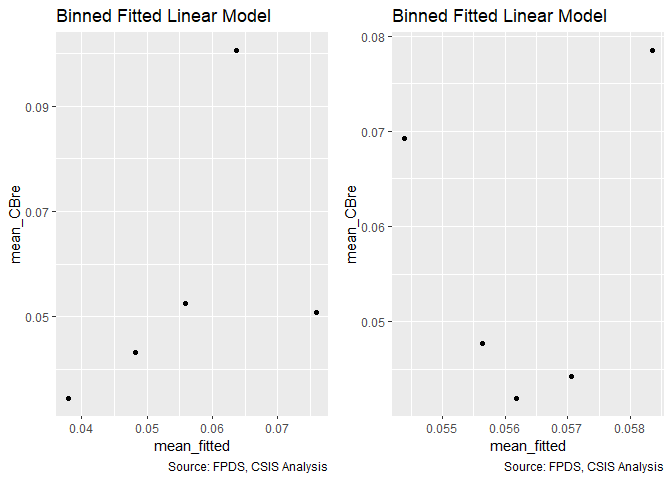

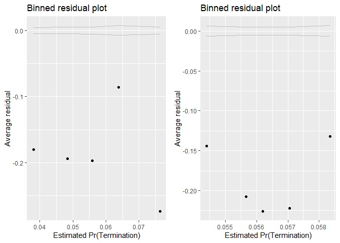

```
## [[1]]
##        model deviance null.deviance difference
## 1 model1_old 107471.6      108365.4 893.729735
## 2 model1_new 108355.9      108365.4   9.509405
##
## [[2]]
##   cl_def6_HHI_lag1 cl_def6_ratio_lag1
##           1.049186           1.049186
```

```r
summary_residual_compare(b_CBre09D,b_CBre09D2)
```

The hypothesis is upheld. Deviance is a little lower and residuals a little higher than the prior forms of consolidation for the level 3 model. For the level 6 model, deviance is reduced some in both cases.

NAICS Subsector (Level 3)  
HHI (logged, + means more consolidation) cl_def3_HHI_lag1+ + ++ - Ratio Def. obligatons : US revenue cl_def3_ratio_lag1+ + + -

Ratio at either level is no longer in line with expectations for ceiling breaches.

#### Model 09E: Cumulative Model

Consolidation at lessa nd more granular levels may have different effects. Efficiencies are often used to describe sectors, like utilities, with high barriers to entry. Many of these aspects seem like they would already be captured at less granular NAICS levels, e.g. power plants, rather than more specific NAICS levels, like solar vs. coal. As a result, consolidation for more granular NAICS codes should estimate higher rates of ceiling breaches compared to less granular NAICS code.

We’ll start by adding in everything from both models and seeing what violates VIF.

```r
#Frequency Plot for unlogged ceiling


#Model
b_CBre09E <- glm (data=serv_smp,
                 b_CBre ~  cl_US6_avg_sal_lag1Const +
                   cl_CFTE+ c_pPBSC+c_pOffPSC+
                 c_pairHist+cl_pairCA +
                   cl_Ceil + capped_cl_Days+
                   Comp1or5+
                   Veh+
                   PricingUCA+
                   Crisis+
                   cl_def6_HHI_lag1+cl_def6_ratio_lag1, family=binomial(link="logit"))
glmer_examine(b_CBre09E)
```

```
##                              GVIF Df GVIF^(1/(2*Df))
## cl_US6_avg_sal_lag1Const 1.428685  1        1.195276
## cl_CFTE                  1.309429  1        1.144303
## c_pPBSC                  1.368699  1        1.169914
## c_pOffPSC                1.728981  1        1.314907
## c_pairHist               1.277382  1        1.130213
## cl_pairCA                1.969033  1        1.403222
## cl_Ceil                  1.474374  1        1.214238
## capped_cl_Days           1.397938  1        1.182344
## Comp1or5                 1.246220  3        1.037367
## Veh                      1.737766  4        1.071517
## PricingUCA               1.171549  6        1.013281
## Crisis                   1.346992  3        1.050899
## cl_def6_HHI_lag1         1.380633  1        1.175003
## cl_def6_ratio_lag1       1.220476  1        1.104751
```

```r
n_CBre09E <- glm(data=serv_smp,
                        ln_CBre ~  cl_US6_avg_sal_lag1Const +
                   cl_CFTE+ c_pPBSC+c_pOffPSC+
                 c_pairHist+cl_pairCA+
                 cl_Ceil + capped_cl_Days+
                 Comp1or5+
                   Veh+
                   PricingUCA+
                   Crisis+
                 cl_def6_HHI_lag1+cl_def6_ratio_lag1)

glmer_examine(n_CBre09E)
```

```
##                              GVIF Df GVIF^(1/(2*Df))
## cl_US6_avg_sal_lag1Const 1.416379  1        1.190117
## cl_CFTE                  1.365589  1        1.168584
## c_pPBSC                  2.311410  1        1.520332
## c_pOffPSC                3.238787  1        1.799663
## c_pairHist               1.373715  1        1.172056
## cl_pairCA                2.534274  1        1.591940
## cl_Ceil                  1.956864  1        1.398880
## capped_cl_Days           1.615798  1        1.271140
## Comp1or5                 1.304361  3        1.045281
## Veh                      2.034452  4        1.092838
## PricingUCA               1.214249  6        1.016309
## Crisis                   1.220162  3        1.033720
## cl_def6_HHI_lag1         1.806462  1        1.344047
## cl_def6_ratio_lag1       1.129554  1        1.062805
```

```r
#Plot residuals versus fitted
stargazer::stargazer(b_CBre08B,b_CBre09D2,b_CBre09E,

                     n_CBre08B,n_CBre09D2,n_CBre09E,
                       type="text",
                       digits=2)
```

```
##
## ================================================================================================
##                                                       Dependent variable:
##                                -----------------------------------------------------------------
##                                             b_CBre                          ln_CBre
##                                            logistic                          normal
##                                   (1)        (2)        (3)        (4)        (5)        (6)
## ------------------------------------------------------------------------------------------------
## cl_US6_avg_sal_lag1Const         -0.01                  0.02     0.26***               0.23***
##                                  (0.02)                (0.02)     (0.04)                (0.04)
##
## cl_CFTE                         0.07***               0.07***    0.28***               0.29***
##                                  (0.02)                (0.02)     (0.04)                (0.04)
##
## c_pPBSC                         -0.18***              -0.18***   -0.32***              -0.29***
##                                  (0.02)                (0.02)     (0.04)                (0.04)
##
## c_pOffPSC                       0.92***               0.97***    -0.49***              -0.51***
##                                  (0.02)                (0.02)     (0.03)                (0.04)
##
## c_pairHist                      -0.07***              -0.07***   0.10***                0.09**
##                                  (0.02)                (0.02)     (0.04)                (0.04)
##
## cl_pairCA                       -0.08***              -0.06**    -0.15***              -0.15***
##                                  (0.02)                (0.02)     (0.05)                (0.05)
##
## cl_Ceil                         0.97***               0.99***    2.92***               2.89***
##                                  (0.02)                (0.02)     (0.04)                (0.04)
##
## capped_cl_Days                   0.06**                0.05**      0.06                 0.08*
##                                  (0.02)                (0.02)     (0.04)                (0.04)
##
## Comp1or51 offer                 -0.16***              -0.15***     0.04                  0.01
##                                  (0.03)                (0.03)     (0.06)                (0.06)
##
## Comp1or52-4 offers              0.31***               0.31***    -0.24***              -0.23***
##                                  (0.02)                (0.02)     (0.04)                (0.04)
##
## Comp1or55+ offers               0.38***               0.37***    -0.15***              -0.15***
##                                  (0.03)                (0.03)     (0.04)                (0.04)
```

[output cut: 40 more lines]

```
## cl_def6_HHI_lag1                           0.05***     -0.03*               -1.96***    -0.05
##                                             (0.02)     (0.02)                (0.04)     (0.03)
##
## cl_def6_ratio_lag1                           0.02     -0.24***              0.98***    0.42***
##                                             (0.02)     (0.02)                (0.05)     (0.04)
##
## Constant                        -2.95***   -2.82***   -2.96***   8.65***    9.28***    8.68***
##                                  (0.02)     (0.01)     (0.02)     (0.04)     (0.02)     (0.04)
##
## ------------------------------------------------------------------------------------------------
## Observations                    250,000    250,000    250,000     15,018     15,018     15,018
## Log Likelihood                 -50,713.94 -54,177.93 -50,652.78 -30,237.41 -35,239.75 -30,183.41
## Akaike Inf. Crit.              101,477.90 108,361.90 101,359.60 60,524.83  70,485.50  60,420.83
## ================================================================================================
## Note:                                                                *p<0.1; **p<0.05; ***p<0.01
```

```r
#summary_residual_compare(b_CBre09D2,b_CBre09E)
#summary_residual_compare(b_CBre08B,b_CBre09E)
```

Expectations are not upheld.

### Level 3

#### Model 10A: cl_def3_HHI

HHI (logged, + means more consolidation) cl_def3_HHI_lag1+ + ++ -

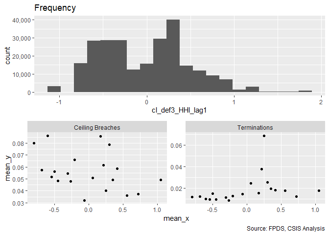

```r
#Frequency Plot for unlogged ceiling
summary_continuous_plot(serv_smp,"cl_def3_HHI_lag1")
```

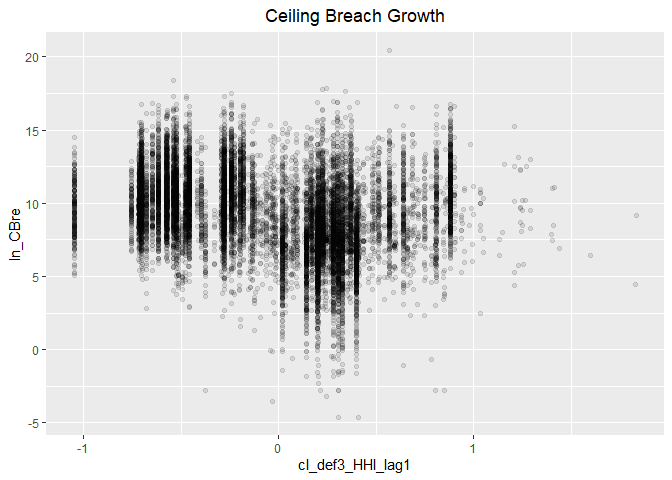

```r
#Scatter Plot
ggplot(serv_smp, aes(x=cl_def3_HHI_lag1, y=ln_CBre)) + geom_point(alpha = 0.1) + ggtitle('Ceiling Breach Growth') + theme(plot.title = element_text(hjust = 0.5))
```

```r
#Model
b_CBre10A <- glm (data=serv_smp,
                 b_CBre ~ cl_def3_HHI_lag1, family=binomial(link="logit"))
display(b_CBre10A)
```

```
## glm(formula = b_CBre ~ cl_def3_HHI_lag1, family = binomial(link = "logit"),
##     data = serv_smp)
##                  coef.est coef.se
## (Intercept)      -2.83     0.01
## cl_def3_HHI_lag1 -0.24     0.02
## ---
##   n = 250000, k = 2
##   residual deviance = 108185.2, null deviance = 108365.4 (difference = 180.2)
```

```r
n_CBre10A <- glm(data=serv_smp,
                        ln_CBre ~ cl_def3_HHI_lag1)

display(n_CBre10A)
```

```
## glm(formula = ln_CBre ~ cl_def3_HHI_lag1, data = serv_smp)
##                  coef.est coef.se
## (Intercept)       9.16     0.02
## cl_def3_HHI_lag1 -1.58     0.05
## ---
##   n = 15018, k = 2
##   residual deviance = 106193.7, null deviance = 114568.9 (difference = 8375.2)
##   overdispersion parameter = 7.1
##   residual sd is sqrt(overdispersion) = 2.66
```

```r
#Plot residuals versus fitted
stargazer::stargazer(b_CBre09A,b_CBre10A,

                       n_CBre09A,n_CBre10A,
                       type="text",
                       digits=2)
```

```
##
## =============================================================
##                               Dependent variable:
##                   -------------------------------------------
##                          b_CBre                ln_CBre
##                         logistic               normal
##                      (1)        (2)        (3)        (4)
## -------------------------------------------------------------
## cl_def6_HHI_lag1   0.05***               -1.80***
##                     (0.02)                (0.04)
##
## cl_def3_HHI_lag1              -0.24***              -1.58***
##                                (0.02)                (0.05)
##
## Constant           -2.82***   -2.83***   9.28***    9.16***
##                     (0.01)     (0.01)     (0.02)     (0.02)
##
## -------------------------------------------------------------
## Observations       250,000    250,000     15,018     15,018
## Log Likelihood    -54,178.40 -54,092.59 -35,401.66 -35,998.34
## Akaike Inf. Crit. 108,360.80 108,189.20 70,807.32  72,000.67
## =============================================================
## Note:                             *p<0.1; **p<0.05; ***p<0.01
```

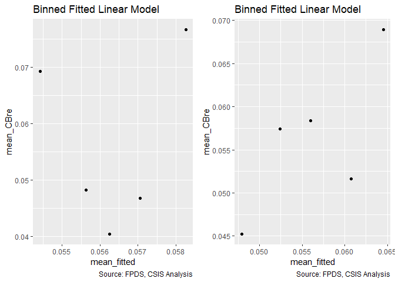

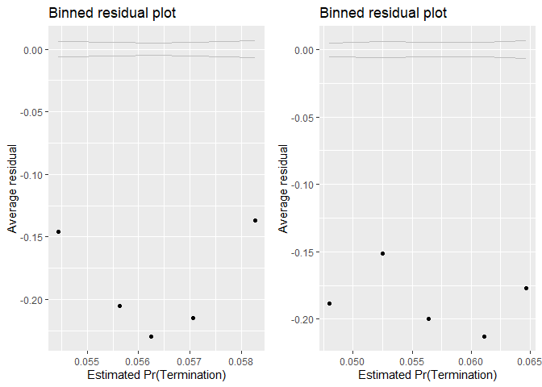

```r
summary_residual_compare(b_CBre09A,b_CBre10A, skip_vif =  TRUE)
```

Contrary to expectation on Ceiling breach and otions growth, in line with expectations on terminations.

#### Model 10B: Defense to Overall ratio

Ratio Def. obligatons : US revenue cl_def3_ratio_lag1+ + + -

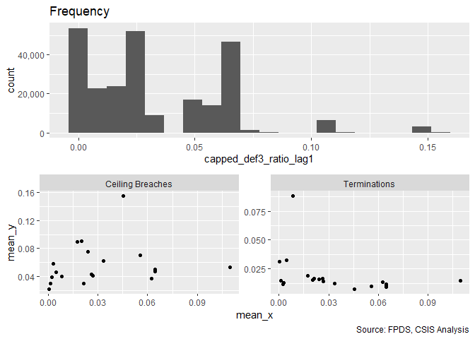

```r
#Frequency Plot for unlogged ceiling
summary_continuous_plot(serv_smp,"capped_def3_ratio_lag1")
```

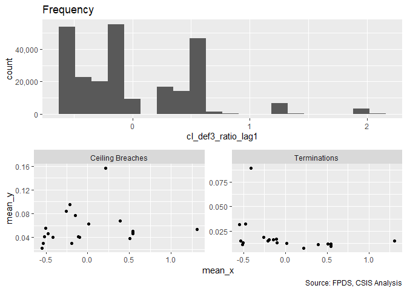

```r
summary_continuous_plot(serv_smp,"cl_def3_ratio_lag1")
```

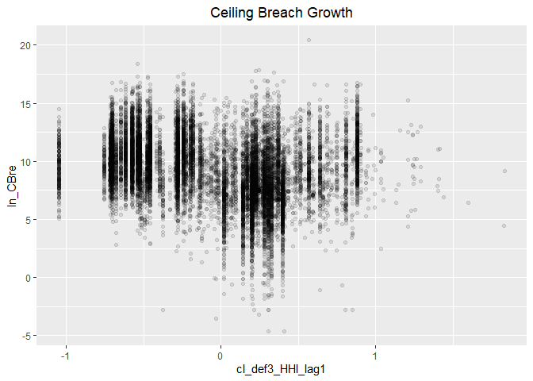

```r
#Scatter Plot
ggplot(serv_smp, aes(x=cl_def3_HHI_lag1, y=ln_CBre)) + geom_point(alpha = 0.1) + ggtitle('Ceiling Breach Growth') + theme(plot.title = element_text(hjust = 0.5))
```

```r
#Model
b_CBre10B <- glm (data=serv_smp,
                 b_CBre ~ cl_def3_ratio_lag1, family=binomial(link="logit"))
display(b_CBre10B)
```

```
## glm(formula = b_CBre ~ cl_def3_ratio_lag1, family = binomial(link = "logit"),
##     data = serv_smp)
##                    coef.est coef.se
## (Intercept)        -2.82     0.01
## cl_def3_ratio_lag1  0.15     0.02
## ---
##   n = 250000, k = 2
##   residual deviance = 108283.3, null deviance = 108365.4 (difference = 82.1)
```

```r
n_CBre10B <- glm(data=serv_smp,
                        ln_CBre ~ cl_def3_ratio_lag1)

display(n_CBre10B)
```

```
## glm(formula = ln_CBre ~ cl_def3_ratio_lag1, data = serv_smp)
##                    coef.est coef.se
## (Intercept)        9.25     0.02
## cl_def3_ratio_lag1 0.16     0.05
## ---
##   n = 15018, k = 2
##   residual deviance = 114488.3, null deviance = 114568.9 (difference = 80.5)
##   overdispersion parameter = 7.6
##   residual sd is sqrt(overdispersion) = 2.76
```

```r
#Plot residuals versus fitted
stargazer::stargazer(b_CBre09B,b_CBre10A,b_CBre10B,

                       n_CBre09B,n_CBre10A,n_CBre10B,
                       type="text",
                       digits=2)
```

```
##
## ====================================================================================
##                                           Dependent variable:
##                    -----------------------------------------------------------------
##                                 b_CBre                          ln_CBre
##                                logistic                          normal
##                       (1)        (2)        (3)        (4)        (5)        (6)
## ------------------------------------------------------------------------------------
## cl_def6_ratio_lag1    0.03                           0.26***
##                      (0.02)                           (0.06)
##
## cl_def3_HHI_lag1               -0.24***                         -1.58***
##                                 (0.02)                           (0.05)
##
## cl_def3_ratio_lag1                        0.15***                          0.16***
##                                            (0.02)                           (0.05)
##
## Constant            -2.82***   -2.83***   -2.82***   9.25***    9.16***    9.25***
##                      (0.01)     (0.01)     (0.01)     (0.02)     (0.02)     (0.02)
##
## ------------------------------------------------------------------------------------
## Observations        250,000    250,000    250,000     15,018     15,018     15,018
## Log Likelihood     -54,181.42 -54,092.59 -54,141.64 -36,557.98 -35,998.34 -36,563.08
## Akaike Inf. Crit.  108,366.80 108,189.20 108,287.30 73,119.97  72,000.67  73,130.15
## ====================================================================================
## Note:                                                    *p<0.1; **p<0.05; ***p<0.01
```

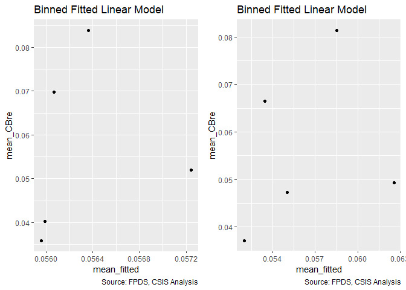

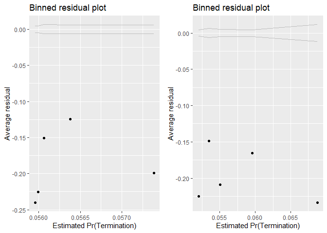

```r
summary_residual_compare(b_CBre09B,b_CBre10B, skip_vif = TRUE)
```

Consolidation at lessa nd more granular levels may have different effects. Efficiencies are often used to describe sectors, like utilities, with high barriers to entry. Many of these aspects seem like they would already be captured at less granular NAICS levels, e.g. power plants, rather than more specific NAICS levels, like solar vs. coal. As a result, consolidation for more granular NAICS codes should estimate higher rates of ceiling breaches compared to less granular NAICS code.

We’ll start by adding in everything from both models and seeing what violates VIF.

```r
#Frequency Plot for unlogged ceiling



#Model
b_CBre10C <- glm (data=serv_smp,
                 b_CBre ~ cl_def3_HHI_lag1+cl_def3_ratio_lag1, family=binomial(link="logit"))
glmer_examine(b_CBre10C)
```

```
##   cl_def3_HHI_lag1 cl_def3_ratio_lag1
##           1.017251           1.017251
```

```r
n_CBre10C <- glm(data=serv_smp,
                        ln_CBre ~ cl_def3_HHI_lag1+cl_def3_ratio_lag1)
glmer_examine(n_CBre10C)
```

```
##   cl_def3_HHI_lag1 cl_def3_ratio_lag1
##           1.000182           1.000182
```

```r
#Plot residuals versus fitted
stargazer::stargazer(b_CBre09E,b_CBre10A,b_CBre10B,b_CBre10C,

                     n_CBre09E,n_CBre10A,n_CBre10B,n_CBre10C,
                       type="text",
                       digits=2)
```

```
##
## ======================================================================================================================
##                                                                  Dependent variable:
##                                ---------------------------------------------------------------------------------------
##                                                  b_CBre                                      ln_CBre
##                                                 logistic                                     normal
##                                   (1)        (2)        (3)        (4)        (5)        (6)        (7)        (8)
## ----------------------------------------------------------------------------------------------------------------------
## cl_US6_avg_sal_lag1Const          0.02                                      0.23***
##                                  (0.02)                                      (0.04)
##
## cl_CFTE                         0.07***                                     0.29***
##                                  (0.02)                                      (0.04)
##
## c_pPBSC                         -0.18***                                    -0.29***
##                                  (0.02)                                      (0.04)
##
## c_pOffPSC                       0.97***                                     -0.51***
##                                  (0.02)                                      (0.04)
##
## c_pairHist                      -0.07***                                     0.09**
##                                  (0.02)                                      (0.04)
##
## cl_pairCA                       -0.06**                                     -0.15***
##                                  (0.02)                                      (0.05)
##
## cl_Ceil                         0.99***                                     2.89***
##                                  (0.02)                                      (0.04)
##
## capped_cl_Days                   0.05**                                      0.08*
##                                  (0.02)                                      (0.04)
##
## Comp1or51 offer                 -0.15***                                      0.01
##                                  (0.03)                                      (0.06)
##
## Comp1or52-4 offers              0.31***                                     -0.23***
##                                  (0.02)                                      (0.04)
##
## Comp1or55+ offers               0.37***                                     -0.15***
##                                  (0.03)                                      (0.04)
```

[output cut: 46 more lines]

```
## cl_def3_HHI_lag1                           -0.24***              -0.22***              -1.58***              -1.58***
##                                             (0.02)                (0.02)                (0.05)                (0.05)
##
## cl_def3_ratio_lag1                                    0.15***    0.13***                          0.16***    0.18***
##                                                        (0.02)     (0.02)                           (0.05)     (0.05)
##
## Constant                        -2.96***   -2.83***   -2.82***   -2.83***   8.68***    9.16***    9.25***    9.15***
##                                  (0.02)     (0.01)     (0.01)     (0.01)     (0.04)     (0.02)     (0.02)     (0.02)
##
## ----------------------------------------------------------------------------------------------------------------------
## Observations                    250,000    250,000    250,000    250,000     15,018     15,018     15,018     15,018
## Log Likelihood                 -50,652.78 -54,092.59 -54,141.64 -54,066.60 -30,183.41 -35,998.34 -36,563.08 -35,990.96
## Akaike Inf. Crit.              101,359.60 108,189.20 108,287.30 108,139.20 60,420.83  72,000.67  73,130.15  71,987.93
## ======================================================================================================================
## Note:                                                                                      *p<0.1; **p<0.05; ***p<0.01
```

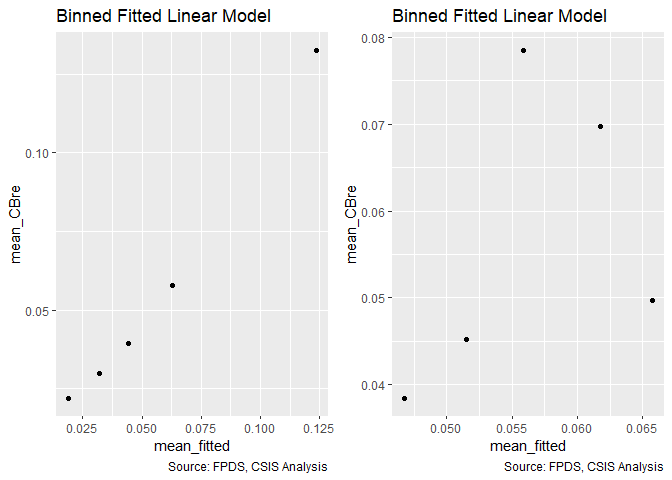

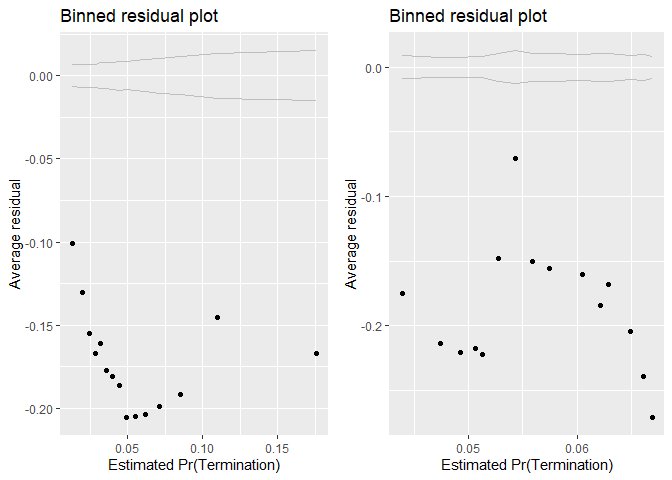

```
## [[1]]
##        model deviance null.deviance difference
## 1 model1_old 101427.9      108365.4  6937.4745
## 2 model1_new 108133.2      108365.4   232.1545
##
## [[2]]
##   cl_def3_HHI_lag1 cl_def3_ratio_lag1
##           1.017251           1.017251
```

```r
summary_residual_compare(b_CBre08B,b_CBre10C)
```

NAICS Subsector (Level 3)  
HHI (logged, + means more consolidation) cl_def3_HHI_lag1+ + ++ - Ratio Def. obligatons : US revenue cl_def3_ratio_lag1+ + + -

#### Model 10D: Cumulative Model

.

```r
#Frequency Plot for unlogged ceiling


#Model
b_CBre10D <- glm (data=serv_smp,
                 b_CBre ~  cl_US6_avg_sal_lag1Const +
                   cl_CFTE+ c_pPBSC+c_pOffPSC+
                 c_pairHist+cl_pairCA +
                   cl_Ceil + capped_cl_Days+
                   Comp1or5+
                   Veh+
                   PricingUCA+
                   Crisis+
                   cl_def6_HHI_lag1+cl_def6_ratio_lag1+
                   cl_def3_HHI_lag1+cl_def3_ratio_lag1, family=binomial(link="logit"))
glmer_examine(b_CBre10D)
```

```
##                              GVIF Df GVIF^(1/(2*Df))
## cl_US6_avg_sal_lag1Const 1.661642  1        1.289047
## cl_CFTE                  1.315467  1        1.146938
## c_pPBSC                  1.395188  1        1.181181
## c_pOffPSC                1.849510  1        1.359967
## c_pairHist               1.299333  1        1.139883
## cl_pairCA                2.121995  1        1.456707
## cl_Ceil                  1.483606  1        1.218033
## capped_cl_Days           1.408622  1        1.186854
## Comp1or5                 1.254976  3        1.038578
## Veh                      1.809599  4        1.076956
## PricingUCA               1.206494  6        1.015766
## Crisis                   1.350487  3        1.051353
## cl_def6_HHI_lag1         2.052565  1        1.432677
## cl_def6_ratio_lag1       1.791530  1        1.338480
## cl_def3_HHI_lag1         1.917958  1        1.384904
## cl_def3_ratio_lag1       2.233038  1        1.494335
```

```r
n_CBre10D <- glm(data=serv_smp,
                        ln_CBre ~  cl_US6_avg_sal_lag1Const +
                   cl_CFTE+ c_pPBSC+c_pOffPSC+
                 c_pairHist+cl_pairCA+
                 cl_Ceil + capped_cl_Days+
                 Comp1or5+
                   Veh+
                   PricingUCA+
                   Crisis+
                 cl_def6_HHI_lag1+cl_def6_ratio_lag1+
                 cl_def3_HHI_lag1+cl_def3_ratio_lag1)
glmer_examine(n_CBre10D)
```

```
##                              GVIF Df GVIF^(1/(2*Df))
## cl_US6_avg_sal_lag1Const 1.664981  1        1.290341
## cl_CFTE                  1.392238  1        1.179931
## c_pPBSC                  2.327849  1        1.525729
## c_pOffPSC                3.308943  1        1.819050
## c_pairHist               1.378183  1        1.173960
## cl_pairCA                2.592555  1        1.610141
## cl_Ceil                  1.957761  1        1.399200
## capped_cl_Days           1.624962  1        1.274740
## Comp1or5                 1.310092  3        1.046045
## Veh                      2.085772  4        1.096247
## PricingUCA               1.253552  6        1.019010
## Crisis                   1.229290  3        1.035005
## cl_def6_HHI_lag1         2.880389  1        1.697171
## cl_def6_ratio_lag1       1.642496  1        1.281599
## cl_def3_HHI_lag1         2.125832  1        1.458023
## cl_def3_ratio_lag1       2.073427  1        1.439940
```

```r
#Plot residuals versus fitted
stargazer::stargazer(b_CBre09E,b_CBre10C,b_CBre10D,

                     n_CBre09E,n_CBre10C,n_CBre10D,
                       type="text",
                       digits=2)
```

```
##
## ================================================================================================
##                                                       Dependent variable:
##                                -----------------------------------------------------------------
##                                             b_CBre                          ln_CBre
##                                            logistic                          normal
##                                   (1)        (2)        (3)        (4)        (5)        (6)
## ------------------------------------------------------------------------------------------------
## cl_US6_avg_sal_lag1Const          0.02                -0.07***   0.23***                0.10**
##                                  (0.02)                (0.02)     (0.04)                (0.05)
##
## cl_CFTE                         0.07***                0.05**    0.29***               0.27***
##                                  (0.02)                (0.02)     (0.04)                (0.04)
##
## c_pPBSC                         -0.18***              -0.18***   -0.29***              -0.27***
##                                  (0.02)                (0.02)     (0.04)                (0.04)
##
## c_pOffPSC                       0.97***               0.97***    -0.51***              -0.55***
##                                  (0.02)                (0.02)     (0.04)                (0.04)
##
## c_pairHist                      -0.07***              -0.07***    0.09**                0.07**
##                                  (0.02)                (0.02)     (0.04)                (0.04)
##
## cl_pairCA                       -0.06**                -0.02     -0.15***               -0.09*
##                                  (0.02)                (0.03)     (0.05)                (0.05)
##
## cl_Ceil                         0.99***               0.99***    2.89***               2.90***
##                                  (0.02)                (0.02)     (0.04)                (0.04)
##
## capped_cl_Days                   0.05**                0.05**     0.08*                 0.10**
##                                  (0.02)                (0.02)     (0.04)                (0.04)
##
## Comp1or51 offer                 -0.15***              -0.14***     0.01                 -0.01
##                                  (0.03)                (0.03)     (0.06)                (0.06)
##
## Comp1or52-4 offers              0.31***               0.31***    -0.23***              -0.23***
##                                  (0.02)                (0.02)     (0.04)                (0.04)
##
## Comp1or55+ offers               0.37***               0.37***    -0.15***              -0.15***
##                                  (0.03)                (0.03)     (0.04)                (0.04)
```

[output cut: 46 more lines]

```
## cl_def3_HHI_lag1                           -0.22***   -0.41***              -1.58***    -0.02
##                                             (0.02)     (0.02)                (0.05)     (0.05)
##
## cl_def3_ratio_lag1                         0.13***    -0.07***              0.18***    0.37***
##                                             (0.02)     (0.03)                (0.05)     (0.05)
##
## Constant                        -2.96***   -2.83***   -2.96***   8.68***    9.15***    8.72***
##                                  (0.02)     (0.01)     (0.02)     (0.04)     (0.02)     (0.04)
##
## ------------------------------------------------------------------------------------------------
## Observations                    250,000    250,000    250,000     15,018     15,018     15,018
## Log Likelihood                 -50,652.78 -54,066.60 -50,513.99 -30,183.41 -35,990.96 -30,150.06
## Akaike Inf. Crit.              101,359.60 108,139.20 101,086.00 60,420.83  71,987.93  60,358.12
## ================================================================================================
## Note:                                                                *p<0.1; **p<0.05; ***p<0.01
```